# Credit risk. Dr. Martín Lozano.

Last compiled on: 26/11/2022, 23:02:56.

Abstract

This material relies on John C. Hull (Hull 2015) credit risk chapters and Lore Dirick credit risk DataCamp course. Some mathematical background is skipped to emphasize the data analysis, model logic, discussion, graphical approach and R coding. As in the philosophy of Donald Knuth (Knuth 1984), the objective of this document is to explain to human beings what we want a computer to do as literate programming. This is a work in progress and it is under revision.

```r
# Logistic models
library(gmodels)
library(ggplot2)
library(tidyr)
library(dplyr)
library(pROC)
# Merton model
library(knitr)
library(Sim.DiffProc)
library(bazar) # para la función almost.equal
library(scatterplot3d)
# Copula models
library(MASS)
library(viridis)
library(rayshader)
```

# Loan analysis.

This section relies on the DataCamp course *Credit Risk Modeling in R* by Lore Dirick. However, we incorporate a slightly different database and an extended analysis.

## Explore the database.

Let’s load the data called and then understand its structure. This database is available upon request.

```r
loan_data <- readRDS("loan_data_ARF.rds")
str(loan_data)
```

```
## 'data.frame':    29092 obs. of  10 variables:
##  $ loan_status   : int  0 0 0 0 0 0 1 0 1 0 ...
##  $ loan_amnt     : int  5000 2400 10000 5000 3000 12000 9000 3000 10000 1000 ...
##  $ int_rate      : num  10.6 11 13.5 11 11 ...
##  $ grade         : Factor w/ 7 levels "A","B","C","D",..: 2 3 3 1 5 2 3 2 2 4 ...
##  $ emp_length    : int  10 25 13 3 9 11 0 3 3 0 ...
##  $ home_ownership: Factor w/ 4 levels "MORTGAGE","OTHER",..: 4 4 4 4 4 3 4 4 4 4 ...
##  $ annual_inc    : num  24000 12252 49200 36000 48000 ...
##  $ age           : int  33 31 24 39 24 28 22 22 28 22 ...
##  $ sex           : Factor w/ 2 levels "0","1": 1 1 1 1 2 2 2 2 1 2 ...
##  $ region        : Factor w/ 4 levels "E","N","S","W": 1 1 3 3 2 2 2 2 4 1 ...
```

This could be a typical database taken from any given financial institution like a bank or a firm that uses credit channels to sell their products or services. Here, we have 29,092 observations of 10 variables. Each observation corresponds to one individual loan and each variable allow us to understand the individual and the loan characteristics. One important variable, our dependent variable, is the value of 0 is no default and the value of 1 is default. A default occurs when a borrower is unable to make timely payments, misses payments, or avoids or stops making payments on interest or principal owed. Then, the definition of default depends on the interests and objectives of the analysis. The variable is dichotomic or categorical. Here, we are interested to predict whether a new application will default or not in the future.

Clearly, is past information as we know with certainty whether the individual defaulted (1) or not (0). Past information is helpful to better understand how likely is that one individual may default according to the rest of their variable values. This kind of data could be easily found in most financial firms as they store details about the applicant and its corresponding loan. Past information is useful to train our quantitative models and eventually make predictions of new applicants, and even evaluate our predictions.

We can look at the information in different ways. For example, look at the first 10 rows (out of 29,092) and their corresponding 10 variables.

```r
head(loan_data, 10)
```

|  | loan_status | loan_amnt | int_rate | grade | emp_length | home_ownership | annual_inc | age | sex | region |
| --- | --- | --- | --- | --- | --- | --- | --- | --- | --- | --- |
| 1 | 0 | 5000 | 10.65 | B | 10 | RENT | 24000 | 33 | 0 | E |
| 2 | 0 | 2400 | 10.99 | C | 25 | RENT | 12252 | 31 | 0 | E |
| 3 | 0 | 10000 | 13.49 | C | 13 | RENT | 49200 | 24 | 0 | S |
| 4 | 0 | 5000 | 10.99 | A | 3 | RENT | 36000 | 39 | 0 | S |
| 5 | 0 | 3000 | 10.99 | E | 9 | RENT | 48000 | 24 | 1 | N |
| 6 | 0 | 12000 | 12.69 | B | 11 | OWN | 75000 | 28 | 1 | N |
| 7 | 1 | 9000 | 13.49 | C | 0 | RENT | 30000 | 22 | 1 | N |
| 8 | 0 | 3000 | 9.91 | B | 3 | RENT | 15000 | 22 | 1 | N |
| 9 | 1 | 10000 | 10.65 | B | 3 | RENT | 100000 | 28 | 0 | W |
| 10 | 0 | 1000 | 16.29 | D | 0 | RENT | 28000 | 22 | 1 | E |

The function is used in different contexts. Generating tables like this is only one way we can use it. Here, instead of looking the details of the first 10 rows, we summarize with respect to .

```r
CrossTable(loan_data$home_ownership)
```

```
##
##
##    Cell Contents
## |-------------------------|
## |                       N |
## |         N / Table Total |
## |-------------------------|
##
##
## Total Observations in Table:  29092
##
##
##           |  MORTGAGE |     OTHER |       OWN |      RENT |
##           |-----------|-----------|-----------|-----------|
##           |     12002 |        97 |      2301 |     14692 |
##           |     0.413 |     0.003 |     0.079 |     0.505 |
##           |-----------|-----------|-----------|-----------|
##
##
##
##
```

These tables illustrate the data structure and contents. We can also use two variables instead of one. In particular, instead of counting for home ownership we can add a second dimension like . This allows us to create more informative tables.

```r
CrossTable(loan_data$home_ownership, loan_data$loan_status, prop.r = TRUE,
           prop.c = FALSE, prop.t = FALSE, prop.chisq = FALSE)
```

```
##
##
##    Cell Contents
## |-------------------------|
## |                       N |
## |           N / Row Total |
## |-------------------------|
##
##
## Total Observations in Table:  29092
##
##
##                          | loan_data$loan_status
## loan_data$home_ownership |         0 |         1 | Row Total |
## -------------------------|-----------|-----------|-----------|
##                 MORTGAGE |     10821 |      1181 |     12002 |
##                          |     0.902 |     0.098 |     0.413 |
## -------------------------|-----------|-----------|-----------|
##                    OTHER |        80 |        17 |        97 |
##                          |     0.825 |     0.175 |     0.003 |
## -------------------------|-----------|-----------|-----------|
##                      OWN |      2049 |       252 |      2301 |
##                          |     0.890 |     0.110 |     0.079 |
## -------------------------|-----------|-----------|-----------|
##                     RENT |     12915 |      1777 |     14692 |
##                          |     0.879 |     0.121 |     0.505 |
## -------------------------|-----------|-----------|-----------|
##             Column Total |     25865 |      3227 |     29092 |
## -------------------------|-----------|-----------|-----------|
##
##
```

This table reveals defaults by home ownership. We can use histograms to see one variable distribution. In this case we have the interest rate distribution.

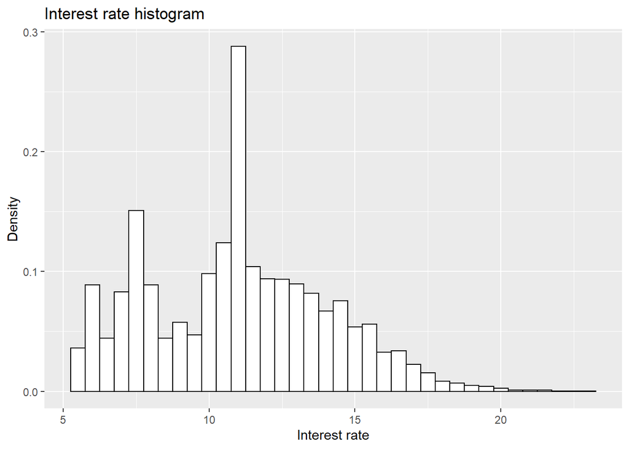

Interest rate histogram.

```r
ggplot(loan_data, aes(x = int_rate)) +
  geom_histogram(aes(y=..density..), binwidth = 0.5, colour = "black",
                 fill = "white") +
  labs(y = "Density",
       x = "Interest rate",
       title = "Interest rate histogram",
       subtitle = NULL) +
  theme(legend.position = "bottom", legend.title = element_blank())
```

The following is a similar figure for the annual income.

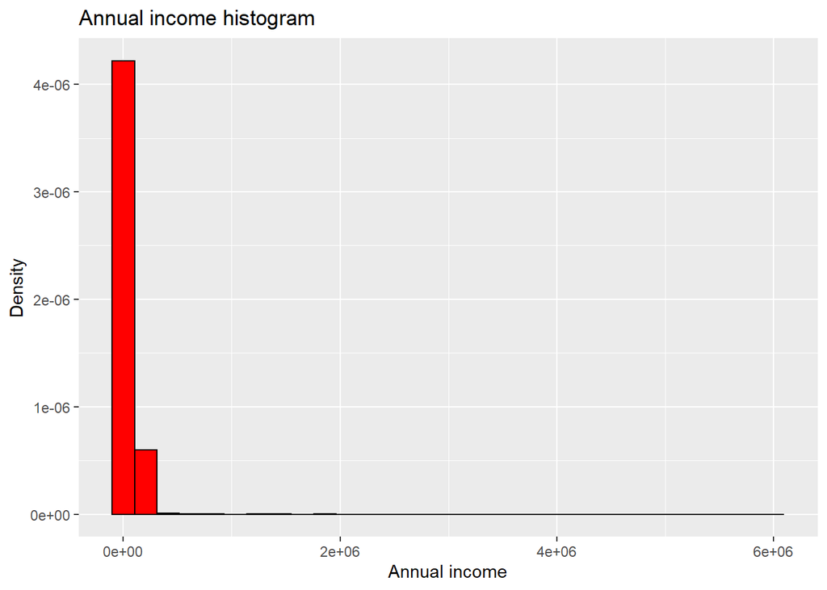

Annual income histogram.

```r
ggplot(loan_data, aes(x = annual_inc)) +
  geom_histogram(aes(y=..density..), colour = "black", fill = "red") +
  labs(y = "Density",
       x = "Annual income",
       title = "Annual income histogram",
       subtitle = NULL) +
  theme(legend.position = "bottom", legend.title = element_blank())
```

The histogram looks suspicious. We have a very large values of the annual income in the horizontal axis (6,000,000) and apparently no observations. We can plot the values and explore the data further as the histogram may be hiding something.

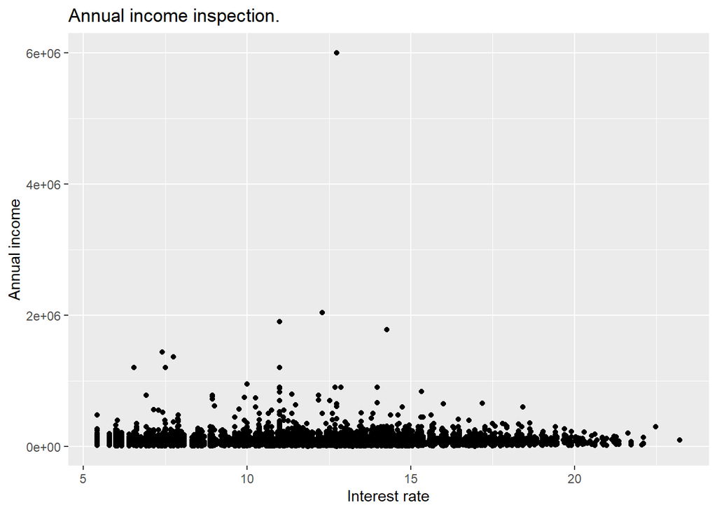

Annual income inspection.

```r
ggplot(loan_data, aes(int_rate, annual_inc)) +
  geom_point() +
  labs(y = "Annual income",
       x = "Interest rate",
       title = "Annual income inspection.",
       subtitle = NULL) +
  theme(legend.position = "bottom", legend.title = element_blank())
```

There are some individuals with a very high income. We should explore further and investigate if this are valid observations or simply a mistake in the original database.

```r
high_income <- loan_data[(loan_data$annual_inc > 1000000), ]
high_income
```

|  | loan_status | loan_amnt | int_rate | grade | emp_length | home_ownership | annual_inc | age | sex | region |
| --- | --- | --- | --- | --- | --- | --- | --- | --- | --- | --- |
| 4861 | 0 | 12025 | 14.27 | C | 13 | RENT | 1782000 | 63 | 0 | E |
| 13931 | 0 | 10000 | 6.54 | A | 16 | OWN | 1200000 | 36 | 0 | W |
| 15386 | 0 | 1500 | 10.99 | A | 5 | MORTGAGE | 1900000 | 60 | 1 | N |
| 16713 | 0 | 12000 | 7.51 | A | 1 | MORTGAGE | 1200000 | 32 | 0 | E |
| 19486 | 0 | 5000 | 12.73 | C | 12 | MORTGAGE | 6000000 | 144 | 1 | E |
| 22811 | 0 | 10000 | 10.99 | A | 1 | MORTGAGE | 1200000 | 40 | 1 | E |
| 23361 | 0 | 6400 | 7.40 | A | 7 | MORTGAGE | 1440000 | 44 | 1 | E |
| 23683 | 0 | 6600 | 7.74 | A | 9 | MORTGAGE | 1362000 | 47 | 0 | E |
| 28468 | 0 | 8450 | 12.29 | C | 0 | RENT | 2039784 | 42 | 0 | E |

One guy is not only rich, he is 144 years old. So, my decision is to drop these 9 observations. Cleaning data is a common task when dealing with large databases. This is fine as long as we do not alter the nature of the data.

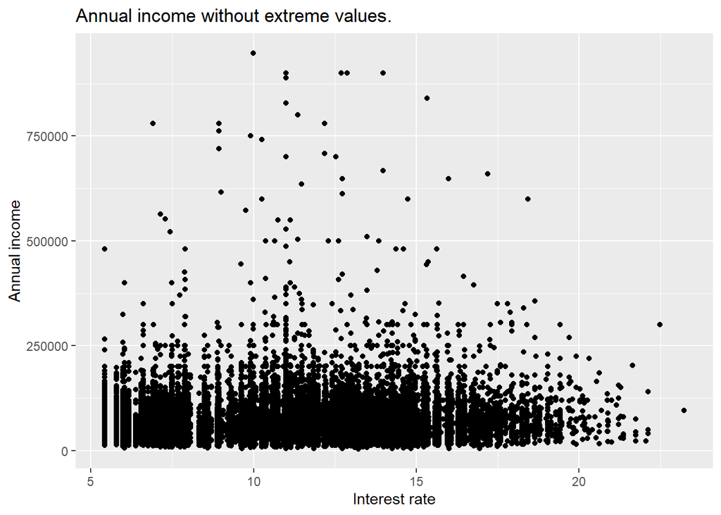

Annual income without extreme values.

```r
high_income_index <- data.frame(value = as.integer(rownames(high_income)))
loan_data <- loan_data[-high_income_index$value,]
ggplot(loan_data, aes(int_rate, annual_inc)) +
  geom_point() +
  labs(y = "Annual income",
       x = "Interest rate",
       title = "Annual income without extreme values.",
       subtitle = NULL) +
  theme(legend.position = "bottom", legend.title = element_blank())
```

Remember the database has originally 29,092 rows and now we are dropping 9 so we end up with 29,083. See the result.

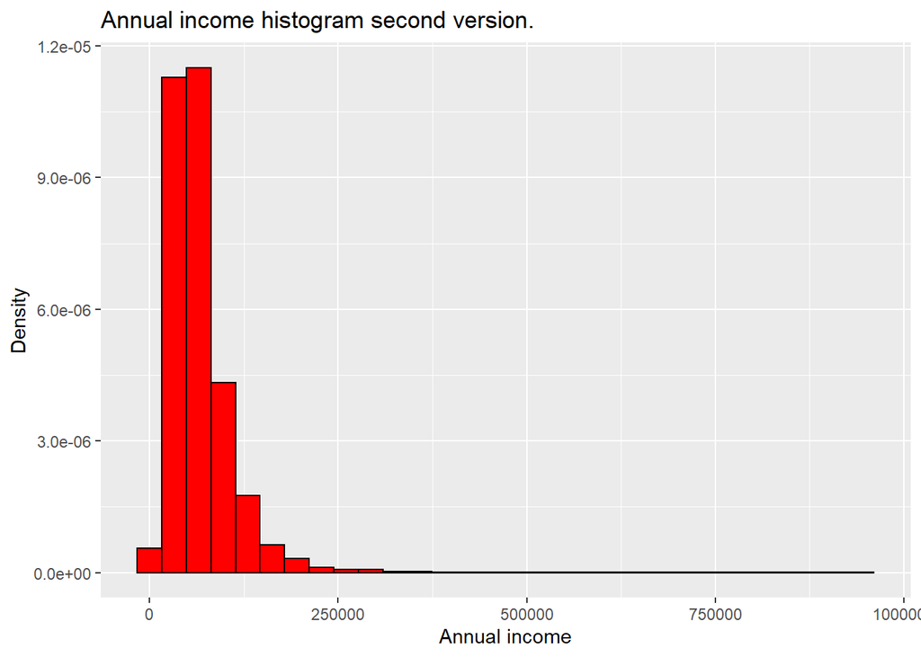

Annual income histogram second version.

```r
ggplot(loan_data, aes(x = annual_inc)) +
  geom_histogram(aes(y=..density..), colour = "black", fill = "red") +
    labs(y = "Density",
       x = "Annual income",
       title = "Annual income histogram second version.",
       subtitle = NULL) +
  theme(legend.position = "bottom", legend.title = element_blank())
```

Somewhat better now.

## Logistic models.

Logistic models allows us to make predictions about loan defaults. Logistic regression is a statistical model that in its basic form uses a logistic function to model a binary dependent variable like . In this case, the binary dependent variable is default or no default. A good reference for this section is Hull (2020).

First, load the data and split it into two sets: (1) training and (2) test. The training set is for building and estimate models and the test set is used to evaluate our model predictions with new data for our models. This is, when estimating models, it is common practice to separate the available data into two portions, *training* and *test* data, where the training data is used to estimate parameters (in-sample) and the test data is used to evaluate its accuracy (out of sample). Because the test data is not used in determining the estimation, it should provide a reliable indication of how well the model is likely to estimate or forecast on new data. In sum, we train the model, we test the model, and once we are OK with the model performance on new data, we are ready to use it in real-life applications. If we ignore this split and use the whole database to produce our models, we may succeed at explaining defaults in our database but we may fail to explain defaults for new loan applications.

```r
# It is convenient to set the loan_status as factor.
loan_data$loan_status <- as.factor(loan_data$loan_status)
set.seed(567)
# idea de Pablo Elizondo usar runif del 1 al nrow(loan_data), eso simplificaria el proces.
index_train <- cbind(runif(1 : nrow(loan_data), 0 , 1),
                     c(1 : nrow(loan_data)))
index_train <- order(index_train[, 1])
index_train <- index_train[1: (2/3 * nrow(loan_data))]
# Create training_set
training_set <- loan_data[index_train, ]
# Create test_set
test_set <- loan_data[-index_train, ]
```

We have 29,083 observations in . The code above randomly selects $29083 \times (2/3)=19388$ rows to form the . The are the remaining $29083-19388=9695$ rows. The random selection is highly recommended as the may have some structure or sorting that could bias our model estimation and negatively impact our model test. For example, imagine that for some weird reason the database is sorted in such a way that the first observations are all no default. If that is the case, then the training and the test set would not have portions of default and no default cases and we may distort the whole analysis. The random selection allow us to replicate a real situation in which our database is unsorted, with different characteristics.

Take a look of the training set structure.

```r
# See the data structure.
str(training_set)
```

```
## 'data.frame':    19388 obs. of  10 variables:
##  $ loan_status   : Factor w/ 2 levels "0","1": 1 1 1 1 1 1 1 1 1 2 ...
##  $ loan_amnt     : int  4000 5000 18000 5600 2700 15000 14500 12000 4800 4050 ...
##  $ int_rate      : num  10.2 14.3 18.3 7.9 14.3 ...
##  $ grade         : Factor w/ 7 levels "A","B","C","D",..: 2 3 6 1 3 2 1 4 1 1 ...
##  $ emp_length    : int  6 3 10 3 5 10 11 9 1 17 ...
##  $ home_ownership: Factor w/ 4 levels "MORTGAGE","OTHER",..: 4 4 4 4 1 1 1 1 4 1 ...
##  $ annual_inc    : num  26000 280000 121000 32000 88500 75000 97600 57600 92000 75000 ...
##  $ age           : int  27 36 24 22 32 23 23 28 48 31 ...
##  $ sex           : Factor w/ 2 levels "0","1": 2 2 2 1 2 1 1 1 2 1 ...
##  $ region        : Factor w/ 4 levels "E","N","S","W": 2 2 2 4 2 4 3 4 2 3 ...
```

Variables as factors are useful for model estimation and data visualization. Factors are variables in R which take on a limited number of different values; such variables are often referred to as categorical variables.

Assume we think that the depends on the age of the individual. We can estimate a simple logistic model to learn about the relationship between age and loan status.

```r
# Fitting a simple logistic model.
log_model_age <- glm(loan_status ~ age, family = "binomial",
                     data = training_set)
log_model_age
```

```
##
## Call:  glm(formula = loan_status ~ age, family = "binomial", data = training_set)
##
## Coefficients:
## (Intercept)          age
##    -1.90097     -0.00623
##
## Degrees of Freedom: 19387 Total (i.e. Null);  19386 Residual
## Null Deviance:       13580
## Residual Deviance: 13580     AIC: 13580
```

Apparently, there is a negative relationship between age and loan status. The AIC value (13580) is useful when comparing models. The Akaike information criterion (AIC) is a mathematical method for evaluating how well a model fits the data it was generated from. In statistics, AIC is used to compare different possible models and determine which one is the best fit for the data. At the moment we cannot interpret the AIC simply because we only have one model and we cannot compare it with another AIC.

Let’s estimate another simple model where the interest rate category is used as a predictor of the . Remember we are not conducting any prediction at all at this moment, we are only estimating models using the training set.

```r
# Build a glm model with variable int_rate as a predictor.
log_model_ir <- glm(formula = loan_status ~ int_rate, family = "binomial",
                     data = training_set)
# Print the parameter estimates.
log_model_ir
```

```
##
## Call:  glm(formula = loan_status ~ int_rate, family = "binomial", data = training_set)
##
## Coefficients:
## (Intercept)     int_rate
##      -3.710        0.142
##
## Degrees of Freedom: 19387 Total (i.e. Null);  19386 Residual
## Null Deviance:       13580
## Residual Deviance: 13210     AIC: 13220
```

The AIC is a lower (13220 versus 13580), so we have a better model now.

Using one single predictor as age or interest rate could be a limited approach. Let’s add some more. Also, let’s introduce the function to extract more information about the model estimation results. The below assumes that the loan status depend on the age, interest rate, grade, loan amount, and annual income.

```r
# Multiple variables in a logistic regression model.
log_model_multi <- glm(loan_status ~ age + int_rate + grade + log(loan_amnt) +
                         log(annual_inc) , family = "binomial",
                       data = training_set)
# Obtain significance levels using summary().
summary(log_model_multi)
```

```
##
## Call:
## glm(formula = loan_status ~ age + int_rate + grade + log(loan_amnt) +
##     log(annual_inc), family = "binomial", data = training_set)
##
## Deviance Residuals:
##     Min       1Q   Median       3Q      Max
## -1.1545  -0.5351  -0.4397  -0.3382   2.6101
##
## Coefficients:
##                  Estimate Std. Error z value Pr(>|z|)
## (Intercept)      1.996240   0.477911   4.177 2.95e-05 ***
## age             -0.002302   0.003825  -0.602   0.5473
## int_rate         0.038767   0.017249   2.247   0.0246 *
## gradeB           0.503409   0.087435   5.758 8.54e-09 ***
## gradeC           0.748229   0.117765   6.354 2.10e-10 ***
## gradeD           0.964343   0.147283   6.548 5.85e-11 ***
## gradeE           1.033442   0.190817   5.416 6.10e-08 ***
## gradeF           1.619470   0.257900   6.279 3.40e-10 ***
## gradeG           1.867494   0.440232   4.242 2.21e-05 ***
## log(loan_amnt)   0.015718   0.036341   0.433   0.6654
## log(annual_inc) -0.470748   0.046423 -10.140  < 2e-16 ***
## ---
## Signif. codes:  0 '***' 0.001 '**' 0.01 '*' 0.05 '.' 0.1 ' ' 1
##
## (Dispersion parameter for binomial family taken to be 1)
##
##     Null deviance: 13579  on 19387  degrees of freedom
## Residual deviance: 13028  on 19377  degrees of freedom
## AIC: 13050
##
## Number of Fisher Scoring iterations: 5
```

Our multi-factor model works well. In , the AIC value is the lowest so far (13050 versus 13220), so this should be considered as the best model at the moment. The function shows the significance levels of the estimators, but we are currently more interested in the goodness of fit of the models because we want to conduct predictions about the . This is, we are interested to use a model to find out whether new applicants in the test set are expected to default or not, rather than in the applicants’ credit risk factors. This is why we are concentrated in AIC now.

When a customer fill out a credit application form, we collect information but we do not know for sure whether she or he will eventually default. A credit risk model can help us in this task.

## Prediction and model evaluation.

Let’s take our three models: , and from the previous subsection to carry out a simple prediction exercise. We start by identifying one observation in the test set and ask the models to estimate the . This is, we take the first guy age, then we apply the model, and compare the predicted with respect to what really happened. Remember we know what really happened with this guy because we have the information in the test set. Every model is expected to produce different estimates. If the model is good, then the predicted will match what really happened.

```r
# Define one single observation in test_set.
test_case <- as.data.frame(test_set[1, ])
test_case
```

|  | loan_status | loan_amnt | int_rate | grade | emp_length | home_ownership | annual_inc | age | sex | region |
| --- | --- | --- | --- | --- | --- | --- | --- | --- | --- | --- |
| 1 | 0 | 5000 | 10.65 | B | 10 | RENT | 24000 | 33 | 0 | E |

We know in advance that the of this observation taken from the test set is 0. However, the models cannot know this simply because we did not use the test set to estimate the logistic models. Our models were estimated using the training set. A good credit risk model should estimate a no default given this new applicant.

The values of in the test set is either 0 or 1. However, the logistic models estimate the as values in the range of 0 to 1. This mean that we would expect the estimated to be close to 0. But, how close? We will deal with this issue later.

```r
# Estimate the loan status with log_model_age and log_model_ir models.
# Esteban Gonzalez, as.numeric no es realmente necesario.
log_model_age_pred <- as.numeric(predict(log_model_age, newdata = test_case,
                              type = "response"))
# Remember the test_case is only one observation (one row).
log_model_ir_pred <- as.numeric(predict(log_model_ir, newdata = test_case,
                              type = "response"))
log_model_multi_pred <- as.numeric(predict(log_model_multi, newdata = test_case,
                              type = "response"))
predictions <- rbind("log_model_age"   = log_model_age_pred,
                     "log_model_ir"    = log_model_ir_pred,
                     "log_model_multi" = log_model_multi_pred)
colnames(predictions) <- "predictions of a known no-default"
predictions
```

```
##                 predictions of a known no-default
## log_model_age                          0.10846236
## log_model_ir                           0.09996702
## log_model_multi                        0.14461840
```

These values are low as they are close to 0. We could interpret this as a certain ability of the models to predict this single case from the test set. However, several questions remains unanswered and requires further analysis. For example: How can we determine if the prediction is low enough to consider it as a non-default? We may need a cut-off value to decide. We will explore this issue later.

Another aspect is: What about the rest of the cases in the test set? We have 9,695 observations in the test set and in the example above we only test for the first one. We are interested in the entire test set, not only for one observation. Fortunately, this issue is easy to address as we only need to change the parameter in the function. In particular, instead of (which is one observation) we can change it to (which is the entire 9,695 test set).

```r
# Estimate the loan status with the three models.
pred_log_model_age <- predict(log_model_age, newdata = test_set,
                              type = "response")
# Now newdata = test_set so we are testing all the test set observations.
pred_log_model_ir <- predict(log_model_ir, newdata = test_set,
                             type = "response")
pred_log_model_multi <- predict(log_model_multi, newdata = test_set,
                                type = "response")
# The range of the estimated loan status.
log_model_age_predall <- range(pred_log_model_age)
log_model_ir_predall <- range(pred_log_model_ir)
log_model_multi_predall <- range(pred_log_model_multi)

predictions_2 <- rbind("log_model_age"   = log_model_age_predall,
                       "log_model_ir"    = log_model_ir_predall,
                       "log_model_multi" = log_model_multi_predall)
aic <- rbind(log_model_age$aic, log_model_ir$aic, log_model_multi$aic)
predictions_2 <- cbind(predictions_2, aic)
colnames(predictions_2) <- c("lower value", "higer value", "AIC")
predictions_2
```

```
##                 lower value higer value      AIC
## log_model_age    0.08417892   0.1165453 13580.65
## log_model_ir     0.05019756   0.3982977 13215.61
## log_model_multi  0.01739107   0.4668004 13050.30
```

Now, instead of the prediction of one single applicant we have conducted a prediction of all 9,695 observations in the test set. The lower value column corresponds to the lower predicted for each model. The logistic models produce values in the range of zero to one, and in this case the ranges are rather narrow.

Narrow ranges (the difference between higher and lower predicted values) could be problematic because the model could not be able to differentiate between defaults (predictions closer to 1) and no-defaults (predictions closer to 0). The higher AIC corresponds to the worst model and the lower AIC to the best model. Here, we can see some consistency because the best model according to the AIC, corresponds to the model with the higher prediction range.

Let’s explore all the predicted values for the :

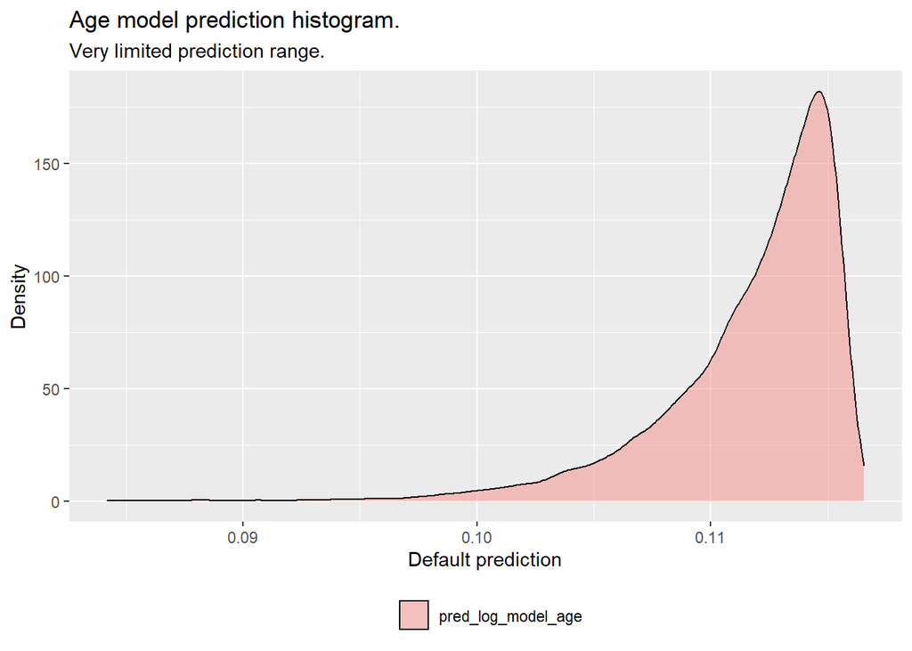

Age model prediction histogram.

```r
pred_log_model_age_plot <- data.frame(pred_log_model_age)
pred_log_model_age_plot <- gather(pred_log_model_age_plot)

ggplot(pred_log_model_age_plot, aes(x = value, fill = key)) +
  geom_density(alpha = 0.4) +
  labs(y = "Density",
       x = "Default prediction",
       title = "Age model prediction histogram.",
       subtitle = "Very limited prediction range.") +
  theme(legend.position = "bottom", legend.title = element_blank())
```

The fails to predict values ranging from 0 to 1. In fact, these values are quite concentrated in a very small range of values. As a consequence, this model fails to differentiate between default and no default predictions.

Let’s visualize the predictions of the and .

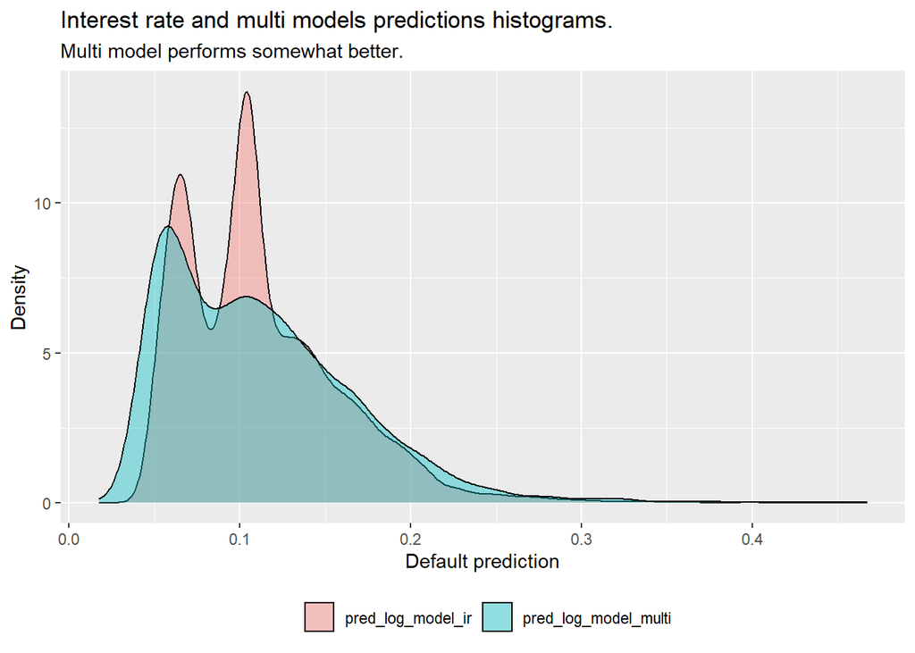

Interest rate and multi models predictions histograms.

```r
pred_ir_multi <- as.data.frame(cbind(pred_log_model_ir,
                                   pred_log_model_multi))
pred_ir_multi <- gather(pred_ir_multi)

ggplot(pred_ir_multi, aes(x = value, fill = key)) +
  geom_density(alpha = 0.4) +
  labs(y = "Density",
       x = "Default prediction",
       title = "Interest rate and multi models predictions histograms.",
       subtitle = "Multi model performs somewhat better.") +
  theme(legend.position = "bottom", legend.title = element_blank())
```

Looks better, but not quite. Presumably, a model which considers all available predictors could be better for predicting the .

```r
# Logistic regression model using all available predictors in the data set.
log_model_full <- glm(loan_status ~ age + int_rate + grade + log(loan_amnt) +
                        log(annual_inc) + emp_length + home_ownership + sex +
                      region, family = "binomial", data = training_set)
#glm(loan_status ~ ., family = "binomial", data = training_set)

# Loan status predictions for all test set elements.
predictions_all_full <- predict(log_model_full, newdata = test_set,
                                type = "response")
# Look at the predictions range.
range(predictions_all_full)
```

```
## [1] 1.422469e-09 8.544424e-01
```

Now, the range is wider. A wider range means that the estimates are now closer to 1. This is good because we need the model to be able to predict both no-defaults (0) and defaults (1). Let’s see a prediction comparisons of and .

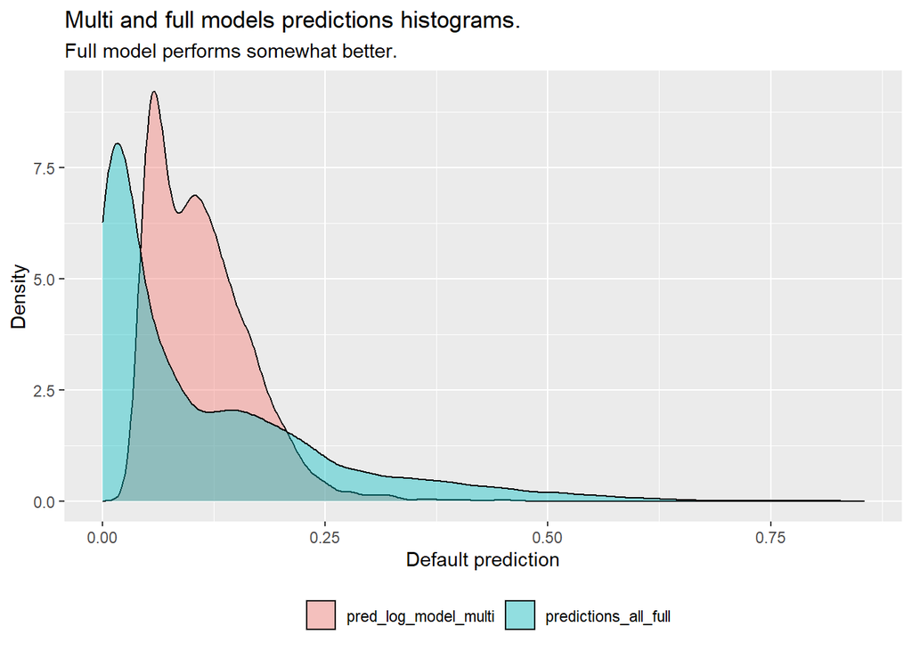

Multi and full models predictions histograms.

```r
predictions_multi_full <-as.data.frame(cbind(pred_log_model_multi,
                                             predictions_all_full))
predictions_multi_full <- gather(predictions_multi_full)

ggplot(predictions_multi_full, aes(x = value, fill = key)) +
  geom_density(alpha = 0.4) +
  labs(y = "Density",
       x = "Default prediction",
       title = "Multi and full models predictions histograms.",
       subtitle = "Full model performs somewhat better.") +
  theme(legend.position = "bottom", legend.title = element_blank())
```

The model predictions looks better than the other models.

Another question is: How can we know these model predictions corresponds to a default or no default? The loan status predictions go from 0 to 0.854 for the case of the model. At the end, these loan status estimations need to be interpreted or classified as a default or no default because we are interested on that. Are they closer enough to 0 to consider a no default? This issue is addressed by setting up a cut-off rate so we can split all estimated loan status into 0 or 1.

Let’s arbitrarily consider a cutoff of 0.15 for now. This mean that every estimated loan status below 0.15 will be considered as 0 (no-default), and every estimated loan status above 0.15 will be considered as 1 (default). Graphically it looks like this:

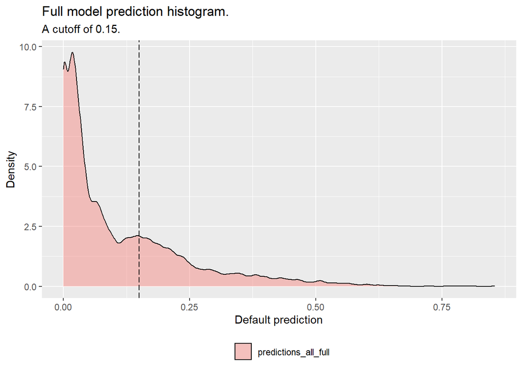

Full model prediction histogram.

```r
pred_log_model_full <- data.frame(predictions_all_full)
pred_log_model_full <- gather(pred_log_model_full)
pred_log_model_full <- mutate(pred_log_model_full,
                              def = ifelse(value < 0.15, 0, 1))
pred_log_model_full$def <- as.factor(pred_log_model_full$def)

ggplot(pred_log_model_full, aes(x = value, fill = key)) +
  geom_density(alpha = 0.4, adjust = 0.4) +
  geom_vline(xintercept = 0.15, linetype = "longdash") +
  labs(y = "Density",
       x = "Default prediction",
       title = "Full model prediction histogram.",
       subtitle = "A cutoff of 0.15.") +
  theme(legend.position = "bottom", legend.title = element_blank())
```

Here, predicted values at the left of the dashed line represent no default and values at the right of the dashed line represent default. Let’s set up the rule to convert the estimated loan status into a binary variable 0 or 1. See how this transformation takes place:

```r
# Make a binary predictions-vector using a cut-off of 15%
pred_cutoff_15 <- ifelse(predictions_all_full > 0.15, 1, 0)
head(cbind(predictions_all_full, pred_cutoff_15))
```

```
##    predictions_all_full pred_cutoff_15
## 1          1.357995e-08              0
## 2          2.986278e-08              0
## 18         2.299645e-02              0
## 26         2.403879e-01              1
## 27         1.778986e-01              1
## 28         2.600172e-02              0
```

These are only the first 6 rows not all of them available in the test set. We can see that the rule works as expected because every estimated loan status below 0.15 is now considered as 0 (no-default), and every estimated loan status above 0.15 is considered as 1 (default). The table above show how we can create this binary variable given the logistic model prediction.

Note that the rows numbers in the table above are 1, 2, 18, 26, 27 and 28. These are not 1, 2, 3, 4, 5 and 6 because the rows were selected randomly out of the . So, the row numbers in the table above correspond to the original place in .

Is a good model after all? We can add a new column to the previous table. This new variable represents what really happened with the loan. Then, the first column is the logistic model prediction, the second column the transformed binary variable given a cutoff of 0.15, and the third column is what actually happened (default or no-default).

```r
# Let's take from rows 101 to 110.
(cbind(predictions_all_full, pred_cutoff_15,
           as.data.frame.numeric(test_set$loan_status)))[101:110,]
```

|  | predictions_all_full | pred_cutoff_15 | test_set$loan_status |
| --- | --- | --- | --- |
| 308 | 1.537106e-01 | 1 | 0 |
| 309 | 4.137654e-02 | 0 | 0 |
| 310 | 3.113926e-02 | 0 | 0 |
| 312 | 5.186962e-09 | 0 | 0 |
| 318 | 5.337092e-02 | 0 | 0 |
| 319 | 8.402239e-02 | 0 | 0 |
| 323 | 2.795535e-01 | 1 | 1 |
| 328 | 5.384112e-09 | 0 | 0 |
| 329 | 1.893745e-01 | 1 | 0 |
| 330 | 9.012136e-03 | 0 | 0 |

Let’s take a sample of 10 observations to conduct the comparison easily. Note that the model correctly predict a no default in most cases. Rows 308 and 329 predict a default incorrectly and row 323 predict a default correctly. There is an easy way to evaluate the rest of the cases in the test set using a simple table called confusion matrix.

```r
# Construct a confusion matrix.
table(test_set$loan_status, pred_cutoff_15)
```

```
##    pred_cutoff_15
##        0    1
##   0 6554 2081
##   1  308  752
```

The model predicts 6,554 of no-defaults correctly and 752 defaults correctly. However, the model predicts 2,081 defaults that are in fact no-defaults and 308 no-defaults that are in fact defaults. How good are these results? Which of these four values is more important? These are questions we address later. For now, we can say that different models and different cut-off rates lead to different confusion matrix results. Please note that adding all these values leads to 9,695 which are the number of observations in the test set.

You may want to see relative and not absolute values. Let’s try the function instead.

```r
CrossTable(test_set$loan_status, pred_cutoff_15, prop.r = TRUE,
           prop.c = FALSE, prop.t = FALSE, prop.chisq = FALSE)
```

```
##
##
##    Cell Contents
## |-------------------------|
## |                       N |
## |           N / Row Total |
## |-------------------------|
##
##
## Total Observations in Table:  9695
##
##
##                      | pred_cutoff_15
## test_set$loan_status |         0 |         1 | Row Total |
## ---------------------|-----------|-----------|-----------|
##                    0 |      6554 |      2081 |      8635 |
##                      |     0.759 |     0.241 |     0.891 |
## ---------------------|-----------|-----------|-----------|
##                    1 |       308 |       752 |      1060 |
##                      |     0.291 |     0.709 |     0.109 |
## ---------------------|-----------|-----------|-----------|
##         Column Total |      6862 |      2833 |      9695 |
## ---------------------|-----------|-----------|-----------|
##
##
```

This table is more informative. The model correctly predicts no-defaults in 75.9% of all the observed no-default cases. In other words, the model fails to predict no-default in 24.1% of the total no-default cases. Now the default. The model correctly predicts the default in 70.9% of all the observed default cases (not bad), and fails to predict default in 29.1% of the total default cases.

Instead of arbitrarily consider a cutoff of 0.15, we can follow a different approach. Now consider that we are interested in taking the 20% highest estimates (closer to 1) of as default. Equivalently, this is to take the lowest 80% estimates (closer to 0) as no-default. Let’s calculate the new cut-off that meets this new criterion.

```r
# Cutoff definition.
cutoff <- quantile(predictions_all_full, 0.8)
cutoff
```

```
##       80%
## 0.1994621
```

This new approach (taking the 20% highest estimates of as default) represent a cut-off of 0.1994621. Graphically:

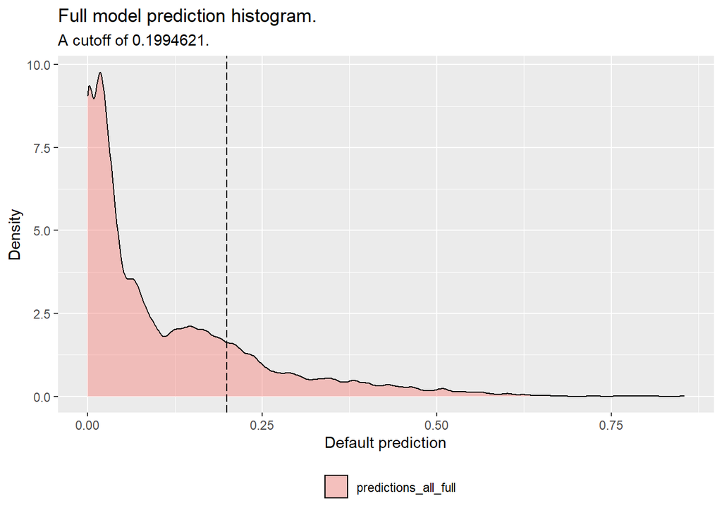

Full model prediction histogram new cutoff.

```r
ggplot(pred_log_model_full, aes(x = value, fill = key)) +
  geom_density(alpha = 0.4, adjust = 0.4) +
  geom_vline(xintercept = cutoff, linetype = "longdash") +
  labs(y = "Density",
       x = "Default prediction",
       title = "Full model prediction histogram.",
       subtitle = "A cutoff of 0.1994621.") +
  theme(legend.position = "bottom", legend.title = element_blank())
```

Now the cut-off is 0.1994621. This splits the loan status predictions into two parts: higher than the cut-off is a default, and lower than the cutoff is a no-default. Taking the lowest 80% estimates (closer to 0) as no-default is an arbitrary decision. Here are the cut-off values depending on this arbitrary decision.

```r
cutoff_all <- quantile(predictions_all_full, seq(0.1, 1, 0.1))
data.frame(cutoff_all)
```

|  | cutoff_all |
| --- | --- |
| 10% | 1.168657e-08 |
| 20% | 1.468925e-02 |
| 30% | 2.410243e-02 |
| 40% | 3.750625e-02 |
| 50% | 6.183830e-02 |
| 60% | 9.617009e-02 |
| 70% | 1.467331e-01 |
| 80% | 1.994621e-01 |
| 90% | 2.922731e-01 |
| 100% | 8.544424e-01 |

We can show a similar summary table as we did with the cutoff of 0.15. Here, we show the predictive ability of the model and new cut-off of 0.1994621.

```r
# Calculate the predictions with the same model and new cutoff.
pred_full_20 <- ifelse(predictions_all_full > cutoff, 1, 0)
# Show results in a confusion matrix.
CrossTable(test_set$loan_status, pred_full_20, prop.r = TRUE,
           prop.c = FALSE, prop.t = FALSE, prop.chisq = FALSE)
```

```
##
##
##    Cell Contents
## |-------------------------|
## |                       N |
## |           N / Row Total |
## |-------------------------|
##
##
## Total Observations in Table:  9695
##
##
##                      | pred_full_20
## test_set$loan_status |         0 |         1 | Row Total |
## ---------------------|-----------|-----------|-----------|
##                    0 |      7309 |      1326 |      8635 |
##                      |     0.846 |     0.154 |     0.891 |
## ---------------------|-----------|-----------|-----------|
##                    1 |       447 |       613 |      1060 |
##                      |     0.422 |     0.578 |     0.109 |
## ---------------------|-----------|-----------|-----------|
##         Column Total |      7756 |      1939 |      9695 |
## ---------------------|-----------|-----------|-----------|
##
##
```

With a cutoff of 0.1994621 we accept 7,309 + 447 applications as those are the ones that the model predicts a no default. We can compare both confusion matrix:

```r
cat <- c("correct no-default", "false default",
         "false no-default", "correct default")
cut_15 <- c(0.759, 0.241, 0.291, 0.709)
cut_19 <- c(0.846, 0.154, 0.422, 0.578)
cbind(cat, cut_15, cut_19)
```

```
##      cat                  cut_15  cut_19
## [1,] "correct no-default" "0.759" "0.846"
## [2,] "false default"      "0.241" "0.154"
## [3,] "false no-default"   "0.291" "0.422"
## [4,] "correct default"    "0.709" "0.578"
```

The new cut-off of 0.1994621 improves the identification of no-defaults but worsen the identification of default. Also, the new cut-off fails less in the default and fails more in the no-default. Apparently there is some sort of trade-off here.

We can also look the detail of 0.1994621 cut-off. Comparing two columns, the one in the left with the actual loan status, and the right column with the estimated loan status.

```r
# Comparative table in detail.
true_and_predval <- cbind.data.frame(test_set$loan_status, pred_full_20,
                                     test_set$loan_status==pred_full_20)
# Show some values.
true_and_predval[131:140,]
```

|  | test_set$loan_status | pred_full_20 | test_set$loan_status == pred_full_20 |
| --- | --- | --- | --- |
| 398 | 0 | 0 | TRUE |
| 399 | 1 | 1 | TRUE |
| 404 | 0 | 1 | FALSE |
| 414 | 0 | 0 | TRUE |
| 417 | 1 | 1 | TRUE |
| 419 | 0 | 0 | TRUE |
| 420 | 0 | 0 | TRUE |
| 425 | 1 | 1 | TRUE |
| 431 | 0 | 0 | TRUE |
| 435 | 0 | 0 | TRUE |

In this sample the model fails in 1 out of 10 individuals. Not bad at all. Let’s imagine we are a bank. We have a total of 9,695 applications for a loan in our desk (or computer). Assume we use the predictions from to decide whether we accept a loan application or not. Our model-based acceptance rule is the following: if then the model estimates a no-default and we accept the loan application. According to the extract of table above, we fortunately reject application 399, 417 and 425 because that was indeed a default. However, we reject application 404 incorrectly because it did not default. In principle, having a model as a base for a decision rule can lead to better results that guessing or a random approval rule.

Let’s count how many applications are accepted and rejected according to our rule.

```r
# Accepted.
accept_20 <- sum(pred_full_20 == 0)
# Rejected.
reject_20 <- sum(pred_full_20 == 1)
data.frame(accept_20, reject_20)
```

| accept_20 | reject_20 |
| --- | --- |
| 7756 | 1939 |

Taking the 20% highest estimates of as default and the lowest 80% as no-default mean that by construction, we accept 7,756 loan applications (80% of the total) and reject 1,939 (20% of the total). Then, the criterion determines the number of accepted applications and the model determines which applications to accept/reject.

We can evaluate our loan application rule as we have the corresponding real values in .

First, let’s illustrate the decision making process given the model estimates.

```r
# First 10 accept decisions.
head(data.frame(true_and_predval[,1:2],
                decision =
                  ifelse(true_and_predval$pred_full_20 == 0,
                         "accept", "reject")), 12)
```

|  | test_set.loan_status | pred_full_20 | decision |
| --- | --- | --- | --- |
| 1 | 0 | 0 | accept |
| 2 | 0 | 0 | accept |
| 18 | 1 | 0 | accept |
| 26 | 0 | 1 | reject |
| 27 | 0 | 0 | accept |
| 28 | 0 | 0 | accept |
| 30 | 0 | 0 | accept |
| 32 | 0 | 0 | accept |
| 34 | 0 | 1 | reject |
| 35 | 0 | 0 | accept |

[output cut: 2 more lines]

We can add an evaluation column.

```r
# First 10 accept decisions.
head(data.frame(true_and_predval[,1:2], decision =
                  ifelse(true_and_predval$pred_full_20 == 0, "accept", "reject"),
                evaluation = ifelse(true_and_predval$pred_full_20 == 1,
                                    "we rejected a good customer",
                                    ifelse(true_and_predval$pred_full_20 == 0 &
  true_and_predval$`test_set$loan_status` == 0,
                       "good decision", "bad decision"))), 12)
```

|  | test_set.loan_status | pred_full_20 | decision | evaluation |
| --- | --- | --- | --- | --- |
| 1 | 0 | 0 | accept | good decision |
| 2 | 0 | 0 | accept | good decision |
| 18 | 1 | 0 | accept | bad decision |
| 26 | 0 | 1 | reject | we rejected a good customer |
| 27 | 0 | 0 | accept | good decision |
| 28 | 0 | 0 | accept | good decision |
| 30 | 0 | 0 | accept | good decision |
| 32 | 0 | 0 | accept | good decision |
| 34 | 0 | 1 | reject | we rejected a good customer |
| 35 | 0 | 0 | accept | good decision |

[output cut: 2 more lines]

Here we have the first 10 accepted loan applications. A good decision is because we accept the loan that did not default. A bad decision is because we accept the loan application and defaulted. We also have some cases in which we rejected a good customer and that is not good.

```r
# We accept loans that the model predicts a no-default (0).
# In "accepted_loans" we know whether the accepted loans are in fact
# default or no-default.
accepted_loans <- true_and_predval[pred_full_20 == 0, 1]
# The code above says: if we accept the application, tell me what happened.
head(accepted_loans, 10)
```

```
##  [1] 0 0 1 0 0 0 0 0 0 1
## Levels: 0 1
```

Here we have the first 10 accepted loans. We fail at the third (which is row 18) and the tenth (which is row 37) as the previous table indicates.

```r
# bad_rate is the proportion of accepted loans that are in fact default.
bad_rate <- sum(accepted_loans == 1)/length(accepted_loans)
bad_rate
```

```
## [1] 0.0576328
```

This is, by following the model-based rule, we accepted 7,756 loan applications that represent 80% of the total applications. However, 5.76% of those accepted applications were in fact a default. In particular, we accepted 447 loans that are defaults so: $447/7756=0.0576328$.

Models are not perfect but we are always interested to find out a good model that leads to a lower bad rate because we do not want to accept many defaults. If we keep the same model and the test set the same, we could reduce this 5.76% by being more strict in the loan application which in simple terms mean to reduce the acceptance rate. This alternative could be controversial as a lower acceptance rate represents lower income (less customers) for the bank or financial firm. In any case, consider we reduce the acceptance rate from 80% to 65% so we can evaluate the impact over the bad rate.

```r
# New cutoff value.
cutoff <- quantile(predictions_all_full, 0.65)
# Split the predictions_all_full into a binary variable.
pred_full_35 <- ifelse(predictions_all_full > cutoff, 1, 0)
# A data frame with real and predicted loan status.
true_and_predval <- cbind.data.frame(test_set$loan_status, pred_full_35)
# Loans that we accept given these new rules.
accepted_loans <- true_and_predval[pred_full_35 == 0, 1]
# Bad rate (accepted loan applications that are defaults).
bad_rate <- sum(accepted_loans == 1)/length(accepted_loans)
# Show the bad rate.
bad_rate
```

```
## [1] 0.03713107
```

As expected, the bad rate is lower (from 5.76%% to 3.71%). This is, the lower the acceptance rate the lower the bad rate. In the extreme, if we accept 0 loan applications then our bad rate would be zero, but doing so is equivalent as going out of business. We can create a function such that given a vector of prediction of loan status we can return the bad rate for different cutoff values. This could be useful to build the *bank strategy* more easily. This function will reveal the trade-off between the acceptance rate and the bad rate. In particular, the lower the acceptance rate, the lower the income (bad thing) and the lower the bad rate (good thing). So, which combination is the optimal?

## The bank strategy.

A bank could be interested to understand the relationship between the acceptance rate and the bad rate given a model that predicts the loan status.

```r
# Function.
strategy_bank <- function(prob_of_def){
cutoff <- rep(NA, 21)
bad_rate <- rep(NA, 21)
accept_rate <- seq(1, 0, by = -0.05)
for (i in 1:21){
  cutoff[i] <- quantile(prob_of_def, accept_rate[i])
  pred_i <- ifelse(prob_of_def > cutoff[i], 1, 0)
  pred_as_good <- test_set$loan_status[pred_i == 0]
  bad_rate[i] <- sum(pred_as_good == 1)/length(pred_as_good)}
table <- cbind(accept_rate, cutoff = round(cutoff, 4),
               bad_rate = round(bad_rate, 4))
return(list(table = table, bad_rate = bad_rate,
            accept_rate = accept_rate, cutoff = cutoff))
}
```

We can evaluate this function for the and a bad model like the . In principle, we expect the model to have a more attractive relationship between the acceptance rate and the bad rate. This is, lower bad rates for a given acceptance rate. Any financial institution could be interested in increasing the acceptance rate without increasing too much the bad rate.

Let’s apply the function to the and the .

```r
# Apply the strategy_bank function.
strategy_predictions_all_full <-
  strategy_bank(as.numeric(predictions_all_full))
strategy_pred_log_model <- strategy_bank(as.numeric(pred_log_model_age))
data.frame(accept_rate = strategy_pred_log_model$accept_rate,
           log_model_bad_rate = strategy_pred_log_model$bad_rate,
           full_model_bad_rate = strategy_predictions_all_full$bad_rate)
```

| accept_rate | log_model_bad_rate | full_model_bad_rate |
| --- | --- | --- |
| 1.00 | 0.10933471 | 0.109334709 |
| 0.95 | 0.10849715 | 0.090662324 |
| 0.90 | 0.10849715 | 0.076790831 |
| 0.85 | 0.10849715 | 0.066626214 |
| 0.80 | 0.10547397 | 0.057632800 |
| 0.75 | 0.10547397 | 0.050612020 |
| 0.70 | 0.10396251 | 0.043619216 |
| 0.65 | 0.10396251 | 0.037131070 |
| 0.60 | 0.10092961 | 0.029396596 |
| 0.55 | 0.10092961 | 0.023443361 |

[output cut: 11 more lines]

The full model is superior because at any acceptance rate we can reach a lower bad rate. A plot can reveal the main differences of these two models: and .

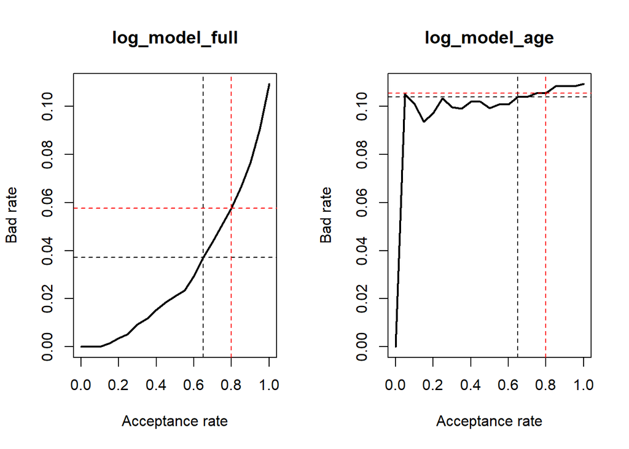

A good and a bad model.

```r
# Plot the strategy functions
par(mfrow = c(1, 2))
plot(strategy_predictions_all_full$accept_rate,
     strategy_predictions_all_full$bad_rate,
     type = "l", xlab = "Acceptance rate", ylab = "Bad rate",
     lwd = 2, main = "log_model_full")
abline(v = strategy_predictions_all_full[["accept_rate"]][8], lty = 2)
abline(h = strategy_predictions_all_full[["bad_rate"]][8], lty = 2)
abline(v = strategy_predictions_all_full[["accept_rate"]][5], lty = 2,
       col = "red")
abline(h = strategy_predictions_all_full[["bad_rate"]][5], lty = 2,
       col = "red")
plot(strategy_pred_log_model$accept_rate,
     strategy_pred_log_model$bad_rate,
     type = "l", xlab = "Acceptance rate",
     ylab = "Bad rate", lwd = 2, main = "log_model_age")
abline(v = strategy_pred_log_model[["accept_rate"]][8], lty = 2)
abline(h = strategy_pred_log_model[["bad_rate"]][8], lty = 2)
abline(v = strategy_pred_log_model[["accept_rate"]][5], lty = 2, col = "red")
abline(h = strategy_pred_log_model[["bad_rate"]][5], lty = 2, col = "red")
```

The model is better because for any acceptance rate we can reach a lower bad rate compared with the . This is because the model can identify defaults and no defaults with higher precision compared with the . The value of a good model is that it can help us to make better business decisions, in this case better credit evaluation decisions.

The model ability to predict defaults and no defaults can be measured by the AUC. The AUC can be defined as the probability that the fit model will score a randomly drawn positive sample higher than a randomly drawn negative sample. AUC stands for area under the curve in the following context:

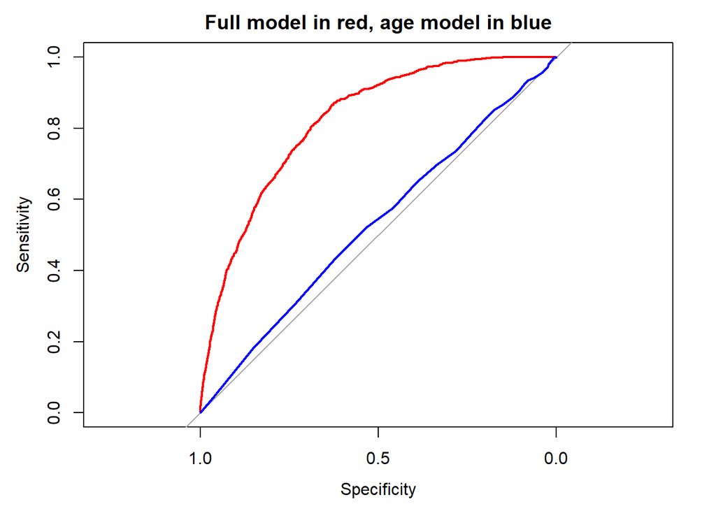

```r
ROC_all_full <- roc(test_set$loan_status, predictions_all_full)
ROC_log_model <- roc(test_set$loan_status, pred_log_model_age)
# Draw the ROCs on one plot
plot(ROC_all_full, col = "red", main = "Full model in red, age model in blue")
lines(ROC_log_model, col = "blue")
```

Sensitivity is the model ability to correctly identify defaults, these are known as true positive. Specificity is the model ability to correctly identify no-default loans, these are known as true negative.

As expected, the area under the curve (AUC) is higher for the red line which corresponds to the model. We can calculate the exact values:

```r
# Compute the AUCs
auc(ROC_all_full)
```

```
## Area under the curve: 0.8213
```

```r
auc(ROC_log_model)
```

```
## Area under the curve: 0.5301
```

Note that the has an AUC of 0.5301. This is close to a loan approval process in which we randomly accept and reject with no further analysis. In other words, the is so bad that it is almost equivalent as using no model at all and accept and reject loan applications based on a random rule. A pure-random approval rule would look like this:

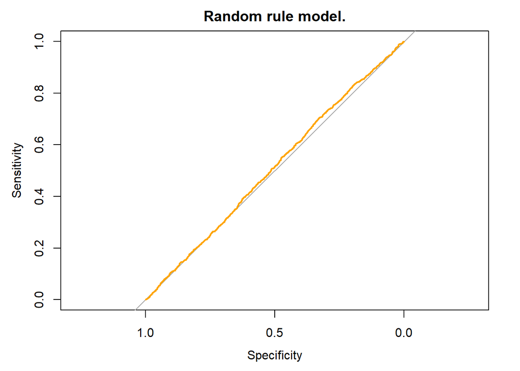

```r
set.seed(2020)
pred_rand_model <- runif(length(pred_log_model_age))
ROC_rand <- roc(test_set$loan_status, pred_rand_model)
# Draw the ROCs on one plot
plot(ROC_rand, col = "orange", main = "Random rule model.")
```

```r
auc(ROC_rand)
```

```
## Area under the curve: 0.5105
```

In theory, this random evaluation process would lead to an AUC of $0.5 = (1 \times 1)/2$. In contrast, now imagine we have a perfect model:

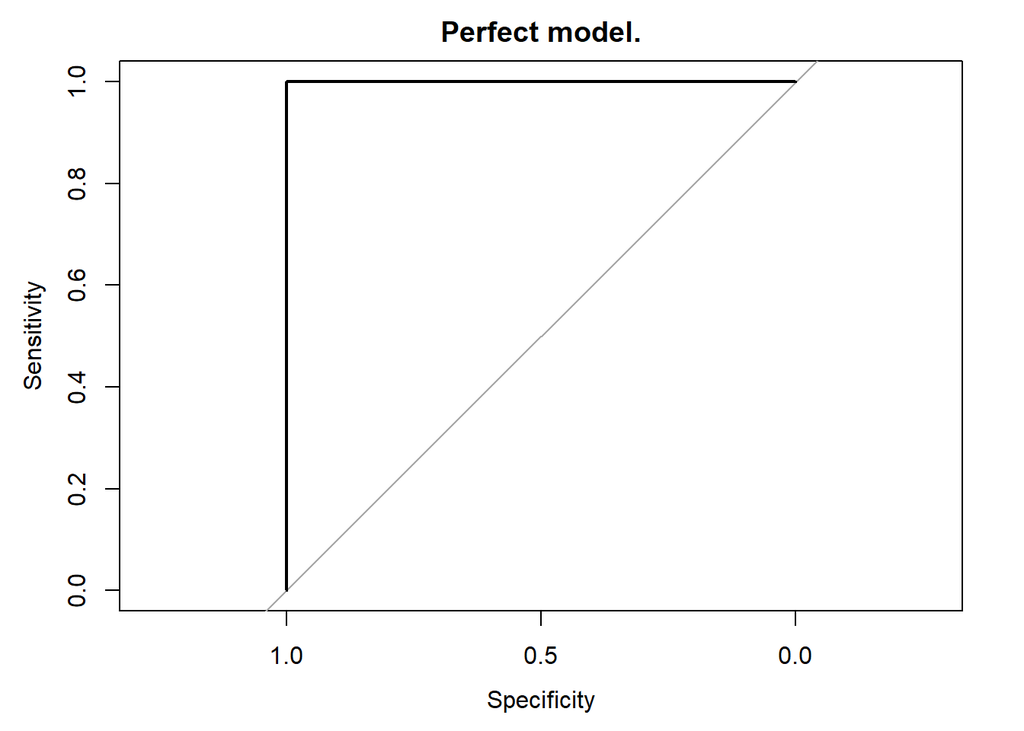

```r
pred_perfect_model <- as.numeric(test_set$loan_status)
ROC_perfect <- roc(test_set$loan_status, pred_perfect_model)
plot(ROC_perfect, main = "Perfect model.")
```

```r
auc(ROC_perfect)
```

```
## Area under the curve: 1
```

In a perfect model, the AUC is equal to 1 ($1 \times 1$). The model correctly identify defaults (100% sensitivity) and at the same time the model correctly identify no-defaults (100% specificity)

# The Merton model.

The Merton model is useful when we are interested to evaluate the credit risk of public firms. In short, it evaluates how likely is that the value of the firm’s assets fall in the future below a certain threshold represented by the firm’s debt. By doing that, the model is able to estimate a probability of default among other results. The model can be used as a tool to propose changes (for example) in the balance sheet to reduce the credit risk exposure of a firm.

## Minimize a function in R.

The estimation of the credit risk Merton’s model requires a minimization of a function. In this section, we show a simple minimization example. Here are some useful online resources for further references.

- [FRM: How d2 in Black-Scholes becomes PD in Merton model.](https://youtu.be/lV0ytJYbVzc)
- [Normal Probability Distribution Graph. Interactive.](https://www.intmath.com/counting-probability/normal-distribution-graph-interactive.php)
- [How to use optim in R.](https://www.r-bloggers.com/how-to-use-optim-in-r/)

The objective function to be minimized is $f(a,b)=\sum(a + bx_i-y_i)^2$. We have six values for $x$ and $y$, and we are expected to minimize the function $f$ by finding the parameter values $a$ and $b$. The $x_i$ and $y_i$ data looks like this:

```r
# Data.
dat <- data.frame(x = c(1, 2, 3, 4, 5, 6), y = c(1, 3, 5, 6, 8, 12))
kable(dat, caption = "Observations.", row.names = TRUE) # The table.
```

Observations.

|  | x | y |
| --- | --- | --- |
| 1 | 1 | 1 |
| 2 | 2 | 3 |
| 3 | 3 | 5 |
| 4 | 4 | 6 |
| 5 | 5 | 8 |
| 6 | 6 | 12 |

Graphically:

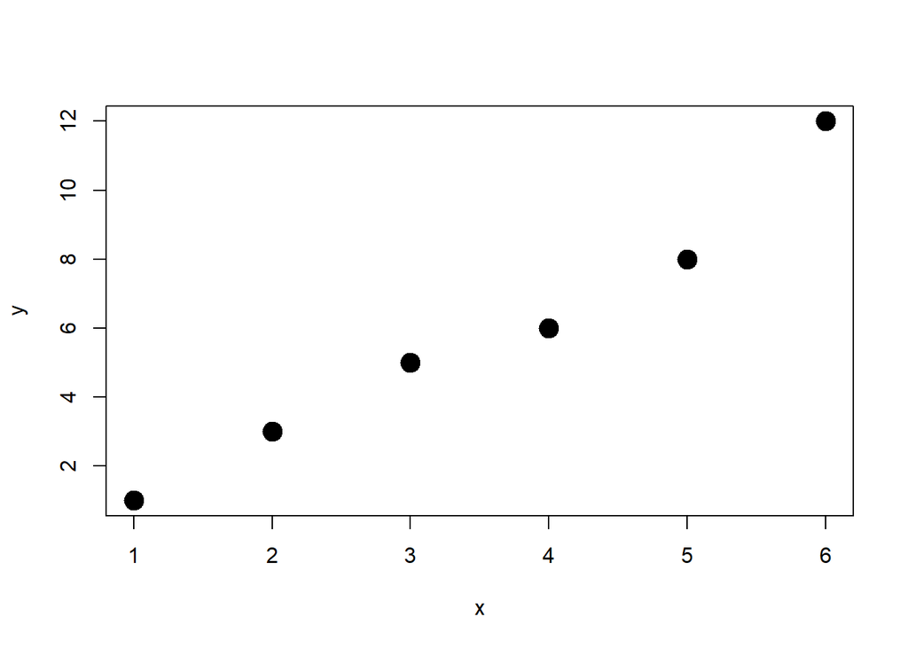

Original data.

```r
# A scatter plot.
plot(y ~ x, data = dat, pch = 19, cex = 2)
```

Let’s implement the minimization.

```r
# Function that calculates the residual sum of squares.
min.RSS <- function(data, par) {
  with(data, sum((par[1] + par[2] * x - y)^2)) }
# Function minimization.
result <- optim(par = c(0, 1), min.RSS, data = dat)
a <- result$par[1]
b <- result$par[2]
f <- sum((a + b * dat$x - dat$y)^2)
# Minimization output.
ans <- data.frame(a, b, f)
kable(ans, caption = "Minimization results f(a,b).")
```

Minimization results f(a,b).

| a | b | f |
| --- | --- | --- |
| -1.266846 | 2.02862 | 2.819048 |

The minimization result is represented by a line, and the line is characterized by an intercept equal to $-1.266846$ and a slope equal to $2.02862$.

We can plot it and verify that this is indeed the right answer.

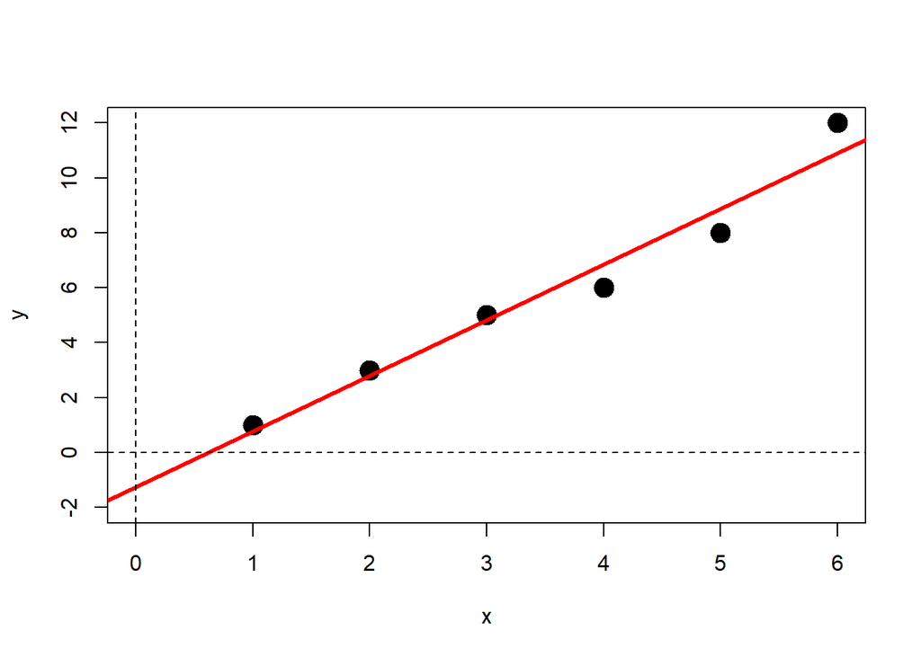

Line that minimize the residual sum of squares.

```r
# View the results.
plot(y ~ x, data = dat, pch = 19, ylim = c(-2, 12), xlim = c(0, 6), cex = 2)
abline(a, b, col = "red", lwd = 3)
abline(h = 0, lty = 2)
abline(v = 0, lty = 2)
```

The function that we minimize here is basically the OLS criterion. This is why the regression model leads to the same results.

```r
# The previous example is equivalent as a linear regression model.
reg <- lm(y ~ x, data = dat)
# See the results.
summary(reg)
```

```
##
## Call:
## lm(formula = y ~ x, data = dat)
##
## Residuals:
##       1       2       3       4       5       6
##  0.2381  0.2095  0.1810 -0.8476 -0.8762  1.0952
##
## Coefficients:
##             Estimate Std. Error t value Pr(>|t|)
## (Intercept)  -1.2667     0.7815  -1.621 0.180388
## x             2.0286     0.2007  10.109 0.000539 ***
## ---
## Signif. codes:  0 '***' 0.001 '**' 0.01 '*' 0.05 '.' 0.1 ' ' 1
##
## Residual standard error: 0.8395 on 4 degrees of freedom
## Multiple R-squared:  0.9623, Adjusted R-squared:  0.9529
## F-statistic: 102.2 on 1 and 4 DF,  p-value: 0.000539
```

The function that we minimize in the estimation of the credit risk Merton model is more elaborated but we follow the same principle as above.

## Applied example.

Let’s follow the example 24.3 in (Hull 2015). Five parameters: $E_0=3$, $\sigma_E=0.8$, $rf=0.05$, $T=1$, $D=10$ lead to an estimate of the value of the assets today $V_0$ and the volatility of the assets $\sigma_V$. With these seven parameters we can estimate the probability of default (pd) among other results.

```r
# List of known parameters.
E0 <- 3 # Value of the equity as today, I recommend market capitalization.
se <- 0.8 # Stock returns volatility.
rf <- 0.05 # Risk-free rate.
TT <- 1 # Maturity.
D <- 10 # Value of the debt. The Bloomberg function DDIS is useful.
# We need equations 24.3 and 24.4 to estimate V0 and sv.
eq24.3 <- function(V0, sv) {
  ((V0 * pnorm((log(V0 / D) + (rf + sv^2 / 2) * TT) / (sv * sqrt(TT))) -
  D * exp(-rf * TT) * pnorm(((log(V0 / D) +
  (rf + sv^2 / 2) * TT) / (sv * sqrt(TT))) - sv * sqrt(TT)) - E0)) }
eq24.4 <- function(V0, sv) {
  ((pnorm((log(V0 / D) + (rf + sv^2 / 2) * TT) / (sv * sqrt(TT))) *
      sv * V0 - se * E0)) }
# Footnote 10 indicates that we should minimize F(x,y)^2+G(x,y)^2
min.footnote10 <- function(x)
  (eq24.3(x[1], x[2]))^2 + (eq24.4(x[1], x[2]))^2
# The minimization leads to the values of V0 and sv.
V0_sv <- optim(c(1, 1), min.footnote10)
# Define the values as parameters.
V0 <- V0_sv$par[1]
sv <- V0_sv$par[2]
# Calculate the probability of default as a function.
PD <- function(V0, sv) {
  pnorm(-(((log(V0 / D) + (rf + sv^2 / 2) * TT) /
             (sv * sqrt(TT))) - sv * sqrt(TT))) }
# Calculate the probability of default given the previous parameters.
pd <- PD(V0, sv)
# Gather the results.
ans <- data.frame(pd, V0, sv)
kable(ans, caption = "Main model results.")
```

Main model results.

| pd | V0 | sv |
| --- | --- | --- |
| 0.1269396 | 12.39578 | 0.2123041 |

Let’s analyze the role of the values of $d_1$, $d_2$, $N(d_1)$ and $N(d_2)$. First we isolate these values.

```r
# Inspect the role of d and N(d).
d1 <- (log(V0 / D) + (rf + sv^2 / 2) * TT) / (sv * sqrt(TT))
d2 <- d1 - sv * sqrt(TT)
Nd1 <- pnorm(d1)
Nd2 <- pnorm(d2)
ans <- data.frame(d1, Nd1, d2, Nd2)
kable(ans, caption = "Inspect the role of d and N(d).")
```

Inspect the role of d and N(d).

| d1 | Nd1 | d2 | Nd2 |
| --- | --- | --- | --- |
| 1.353282 | 0.9120172 | 1.140978 | 0.8730604 |

Now let’s illustrate how $N(-d_2)$ lead to the probability of default given the properties of a standard normal distribution.

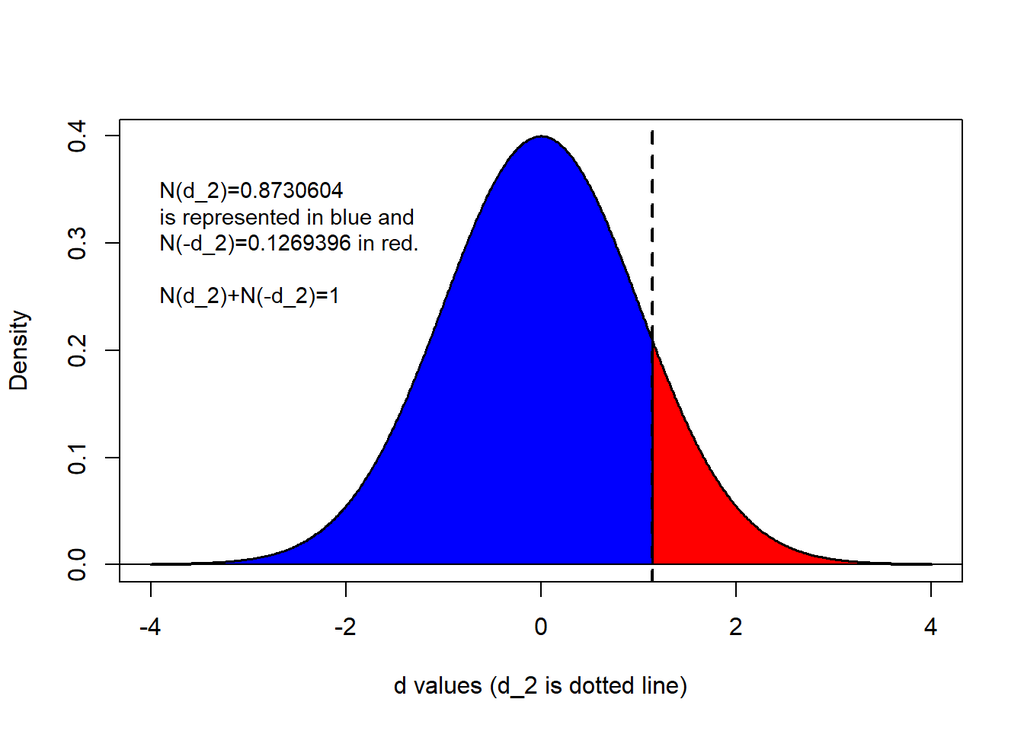

The red area represents the probability of default.

```r
xseq <- seq(-4, 4, 0.01)
densities <- dnorm(xseq, 0, 1) # Standard normal distribution.
# Graphical evaluation of N(-d_2).
plot(xseq, densities, xlab = "d values (d_2 is dotted line)",
     ylab = "Density", type = "l", lwd = 2, cex = 2)
abline(h = 0)
polygon(c(xseq[xseq >= d2], d2), c(densities[xseq >= d2], 0), col = "red")
polygon(c(xseq[xseq < d2], d2), c(densities[xseq < d2], 0), col = "blue")
legend("topleft", legend = c("N(d_2)=0.8730604
is represented in blue and
N(-d_2)=0.1269396 in red.

N(d_2)+N(-d_2)=1"),
bg = "white", bty = "n", cex = 0.9)
abline(v = d2, lty = 2, lwd = 2)
```

Now let’s analyze the minimization that leads to $V_0$ and $\sigma_V$. We do not have an analytic math expressions (closed form) to calculate $V_0$ and $\sigma_V$, instead we have approximate values or estimates given the minimization of equations 24.3 and 24.4. In order to see how good this approximation is, we can retrieve the value of $[F(x,y)]^2+[G(x,y)]^2$ evaluated at $x=V_0$ and $y=\sigma_v$. This value is supposed to be positive as both $F(x,y)$ and $G(x,y)$ functions are squared, so we expect a positive number close to zero when evaluated at $x=V_0$ and $y=\sigma_v$.

```r
# Evaluate how good is the minimization.
min.footnote10(x = c(V0, sv))
```

```
## [1] 1.425797e-07
```

The minimization conducted in the function above worked fairly well.

There is another way to approach how the minimization work. We can propose a graphical analysis. In particular, we can verify whether $V_0=12.39578$ and $\sigma_V=0.2123041$ minimizes the objective function. To illustrate this in two axis, we need to fix either $V_0$ or $\sigma_V$, and evaluate $[F(x,y)]^2+[G(x,y)]^2$ with different values of $V_0$ or $\sigma_V$. Let’s do that.

```r
# Fix sv and evaluate different values of V0.
V0.seq <- seq(from = 4, to = 20, length.out=50)
sv.rep <- rep(sv, 50)
# Function to be evaluated.
FG <- function(V0, sv) { (eq24.3(V0, sv))^2 + (eq24.4(V0, sv))^2 }
# Apply the function with fixed sv and different V0 values.
FG.V0 <- mapply(FG, V0.seq, sv.rep)
```

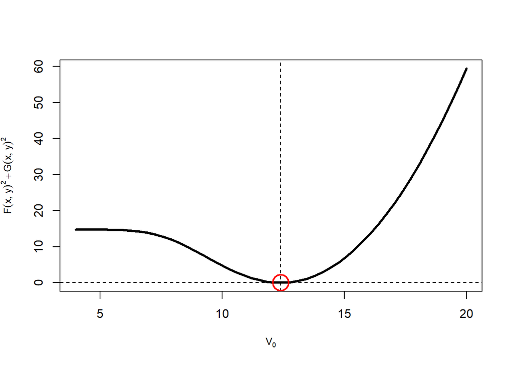

Here we fix the volatility of the assets and change the value of the assets at time zero. The minimization looks fine.

```r
# Plot the results.
plot(V0.seq, FG.V0, type = "l", xlab = expression(paste(V[0])),
     ylab = expression(paste(F(x,y)^2+G(x,y)^2)), cex.lab = 0.8, lwd = 3)
abline(v = V0, lty = 2)
abline(h = FG(V0, sv), lty = 2)
points(V0, FG(V0, sv), pch = 1, cex = 3, col = "red", lwd = 2)
```

Clearly the minimization worked well here. For the sake of completeness, now we fix the $V_0$ value and evaluate the function again.

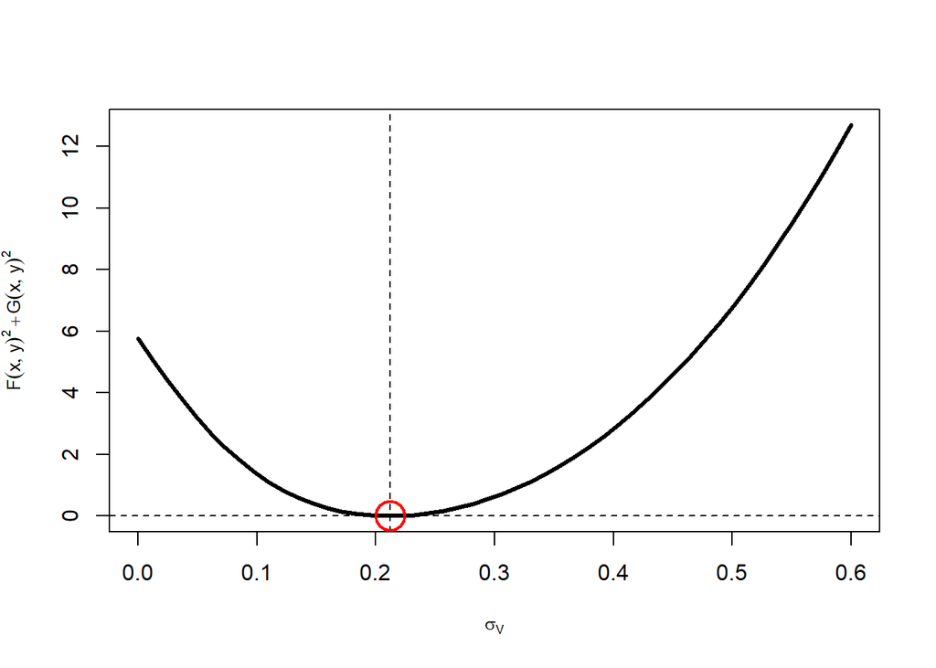

Here we fix the value of the assets at time zero and change the volatility of the assets. The minimization looks fine.

```r
# Now fix V0, and evaluate different sv values.
sv.seq <- seq(0, 0.6, length.out = 50)
V0.rep <- rep(V0, 50)
# Evaluate the function with these parameters.
FG.sv <- mapply(FG, V0.rep, sv.seq)
# Plot the results.
plot(sv.seq, FG.sv, type = "l", xlab = expression(paste(sigma[V])),
     ylab = expression(paste(F(x, y)^2 + G(x, y)^2)),
     cex.lab = 0.8, lwd = 3)
abline(v = sv, lty = 2)
abline(h = FG(V0, sv), lty = 2)
points(sv, FG(V0, sv), pch = 1, cex = 3, col = "red", lwd = 2)
```

We can show the same as before but in a 3D plot.

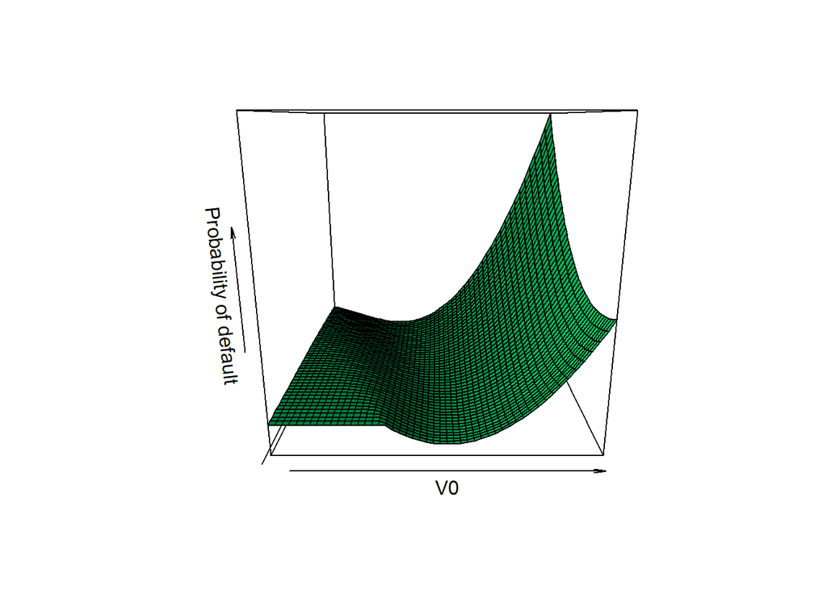

Minimization of the function.

```r
# outer evaluates the function for each combination of the vectors.
z <- outer(V0.seq, sv.seq, FG) # z is now 50x50 matrix.
persp(V0.seq, sv.seq, z, col = "springgreen", shade = 0, xlab = "V0",
      ylab = "sv", zlab = "Probability of default")
```

This green plot is nice but it is not interactive. We could plot interactive three-dimension plots with other R packages like and show them in a html context or java environment. Given that this is a PDF document, we cannot show dynamic plots (at least not yet), so we propose to use contour plots. Contour plots or level plots are a way to show a three-dimensional surface on a two-dimensional plane.

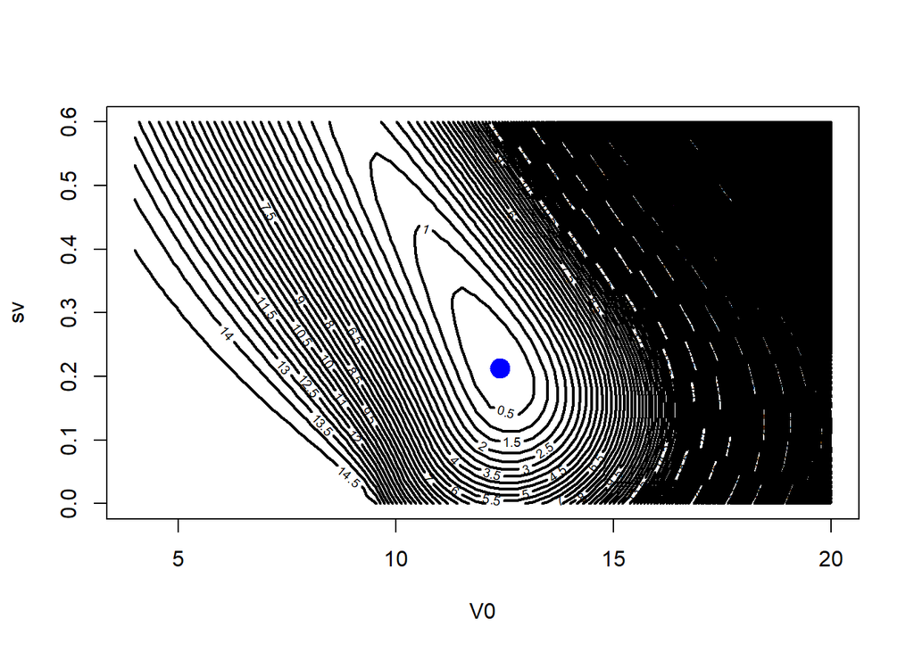

Minimization of the function: a contour view.

```r
# The nlevels is high to emphasize the minimum value in blue.
contour(V0.seq, sv.seq, z, xlab = "V0", ylab = "sv", lwd = 2, nlevels = 300)
points(V0, sv, pch = 19, col = "blue", cex = 2)
```

The following plot cannot be seen in a PDF output, but it can be seen in a browser as an interactive plot.

```r
library(plotly)
p <- plot_ly(x = V0.seq, y = sv.seq, z = z, type = "surface") %>%
layout(
  title = "Minimization of f at V0=12.395 an sv=0.212",
  scene = list(xaxis = list(title = "V0"), yaxis = list(title = "sv"),
    zaxis = list(title = "f=F^2+G^2")))
add_markers(p, x = 12.3957765, y = 0.2123041, z = 0, inherit = TRUE)
```

The Merton model allows us to calculate more values in this credit risk assessment.

```r
# Other results in the Merton's model.
market_value_debt <- V0 - E0
pv_promised_payment_debt <- D * exp(-rf * TT)
Expected_Loss <- (pv_promised_payment_debt - market_value_debt) /
  pv_promised_payment_debt
recovery_rate <- 1 - (Expected_Loss / pd)
ans <- data.frame(market_value_debt, pv_promised_payment_debt,
                  Expected_Loss, recovery_rate, pd)
kable(t(ans), caption = "Other results in the Merton's model.")
```

Other results in the Merton’s model.

| market_value_debt | 9.3957765 |
| --- | --- |
| pv_promised_payment_debt | 9.5122942 |
| Expected_Loss | 0.0122492 |
| recovery_rate | 0.9035039 |
| pd | 0.1269396 |

Could we figure out the implied bond yield spread? It would be similar to the fair interest rate that this firm has to pay given its probability of default and recovery rate. Take Hull’s equation 24.2 as a reference: $\lambda(T)=S(T)/(1-R)$ and solve for $S(T)$: $S(T)=\lambda(T)\times(1-R)$, so $S(T)=(0.12693963)\times(1-0.90350393)$. This is 122.4918 basis points more than the risk-free rate. Then, with five parameters we can calculate (among other things) the firm’s probability of default and the correspondent yield spread of this firm’s bond. It would be interesting to compare this value with the market yield spread and evaluate whether the market yield is over or underestimated according to our theoretical value.

```r
spread <- function(E0, se, rf, TT, D) {
  eq24.3 <- function(V0, sv) {
  ((V0 * pnorm((log(V0 / D) + (rf + sv^2 / 2) * TT) / (sv * sqrt(TT))) -
  D * exp(-rf * TT) * pnorm(((log(V0 / D) +
  (rf + sv^2 / 2) * TT) / (sv * sqrt(TT))) - sv * sqrt(TT)) - E0)) }
eq24.4 <- function(V0, sv) {
  ((pnorm((log(V0 / D) + (rf + sv^2 / 2) * TT) / (sv * sqrt(TT))) *
      sv * V0 - se * E0)) }
  min.footnote10 <- function(x)
  (eq24.3(x[1], x[2]))^2 + (eq24.4(x[1], x[2]))^2
V0_sv <- optim(c(1, 1), min.footnote10)
V0 <- V0_sv$par[1]
sv <- V0_sv$par[2]
pd <- pnorm(-(((log(V0 / D) + (rf + sv^2 / 2) * TT) /
          (sv * sqrt(TT))) - sv * sqrt(TT)))

market_value_debt <- V0 - E0
pv_promised_payment_debt <- D * exp(-rf * TT)
Expected_Loss <- (pv_promised_payment_debt - market_value_debt) /
  pv_promised_payment_debt
recovery_rate <- 1 - (Expected_Loss / pd)
spread <- pd * (1-recovery_rate)
spread
}
```

```r
spread(E0 = 3, se = 0.8, rf = 0.05, TT = 1, D = 10)
```

```
## [1] 0.01224917
```

```r
x.T <- seq(0.5, 10, 0.5)
spread.T <- mapply(spread, E0 = 3, se = 0.8, rf = 0.05, x.T, D = 10)
```

```r
data.frame(x.T, spread.T)
```

| x.T | spread.T |
| --- | --- |
| 0.5 | 0.001436993 |
| 1.0 | 0.012249175 |
| 1.5 | 0.034639827 |
| 2.0 | 0.067649103 |
| 2.5 | 0.109582247 |
| 3.0 | 0.158117325 |
| 3.5 | 0.210872346 |
| 4.0 | 0.265378322 |
| 4.5 | 0.319998224 |
| 5.0 | 0.373117588 |

[output cut: 10 more lines]

## Inside view of the Merton’s model.

The model assumes that the assets follow a geometric Brownian stochastic process. Let’s assume the daily evolution of the market value of the firm assets over a year. Here are 10 simulated paths of $V_t$ from $t=t,...,T$. The reference of this section is Chapter 14 and 15 (John C. Hull).

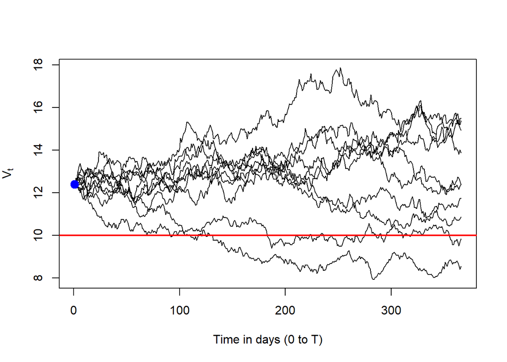

Simulation of 10 paths of the assets.

```r
# Merton assumes V follows a geometric brownian motion process.
V0.sim <- function(i) {  # the argument i is not used here.
  GBM(N = 365, T = 1, t0 = 0, x0 = V0, theta = 0.05, sigma = sv)
  }
set.seed(3) # Reproducibility
paths <- sapply(1:10, V0.sim) # Create 10 paths for V.
# Plot results.
matplot(paths, type ="l", col = "black", lwd = 1, lty = 1,
        ylab = expression(paste(V[t])), xlab = "Time in days (0 to T)")
abline(h = D, col = "red", lwd = 2)
points(1, V0, pch = 19, cex = 1.5, col = "blue")
```

These simulations can be interpreted as the evolution of the value of the firm’s assets in 10 parallel universes. In the past, some students have called this figure *la grafica de los pelitos*, this is OK as long as you understand the figure implications. The right name is 10 simulated geometric brownian processes. Let’s count the cases in which $V_t<D$ note that here I use $t$ and not $T$, so we are counting the cases in which at least at some time $t$ the value of the assets were lower than 10.

```r
# Which path went lower than D?
which(colSums(paths < 10) > 0)
```

```
## [1] 2 4 9
```

The value of the assets was lower than $10 at some time in the second, fourth and ninth alternate universes. Let’s plot these cases.

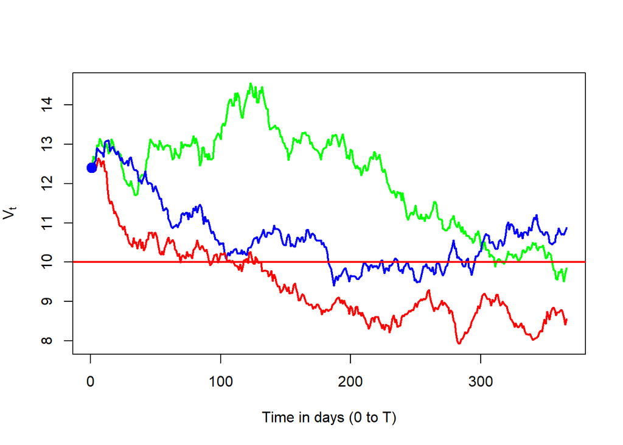

Note that the blue path finally did not default. Recovery is possible as in the real life.

```r
# There might be an easier way to select these cases.
matplot(paths[,which(colSums(paths < 10) > 0)], type = "l",
        col = c("green", "blue", "red"), lwd = 2, lty = 1,
        ylab = expression(paste(V[t])), xlab = "Time in days (0 to T)")
abline(h = D, col = "red", lwd = 2)
points(1, V0, pch = 19, cex = 1.5, col = "blue")
```

The blue path was lower than 10 at some time, but at $t=T$ it is clearly higher than 10. For this reason, the blue path does not represent a firm’s default. See how the assets are not high enough to pay the debt at maturity only in two cases: green and red. Thus, according to this simulation the probability of default is 20%. Here is how we can calculate the cases in which $V_T<D$.

```r
sum(paths[366,] < 10) / 10
```

```
## [1] 0.2
```

The probability of default of 20% can be disappointing because it is significantly higher than 0.12693963. This is because the number of simulations is small. The following examples show how these values tend to converge as we increase the number of simulations from 100 to 100,000.

Here are 100 simulated paths of $V_0$ to $V_T$.

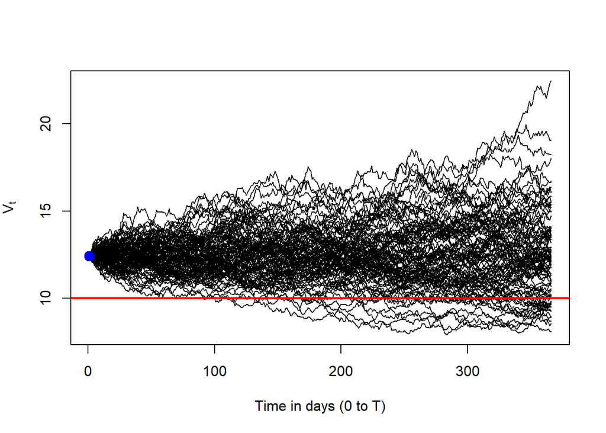

Simulation of 100 paths of the assets.

```r
set.seed(3) # Reproducibility
paths <- sapply(1:100, V0.sim) # Create 100 paths.
# Plot results.
matplot(paths, type = "l", col = "black", lwd = 1, lty = 1,
        ylab = expression(paste(V[t])), xlab = "Time in days (0 to T)")
abline(h = D, col = "red", lwd = 2)
points(1, V0, pch = 19, cex = 1.5, col = "blue")
```

Given the simulation above, the probability of default is 17%. This is closer to 12.693963%.

```r
sum(paths[366,] < 10) / 100
```

```
## [1] 0.17
```

Let’s see all the 17 cases that end in default.

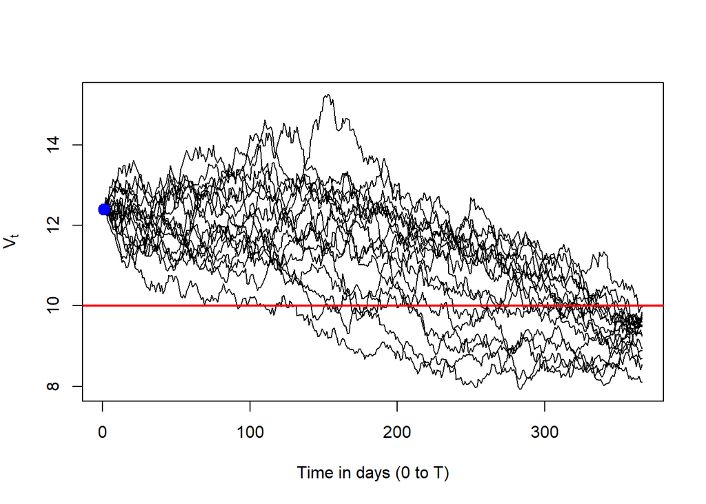

Default cases.

```r
# These are the 17 default cases.
matplot(paths[,which(paths[366,] < 10)], type = "l", col = "black",
        lwd = 1, lty = 1, ylab = expression(paste(V[t])),
        xlab = "Time in days (0 to T)")
abline(h = D, col = "red", lwd = 2)
points(1, V0, pch = 19, cex = 1.5, col = "blue")
```

Now, let’s see the 11 cases in which $V_t$ eventually went lower than $10 but at the end did not default.

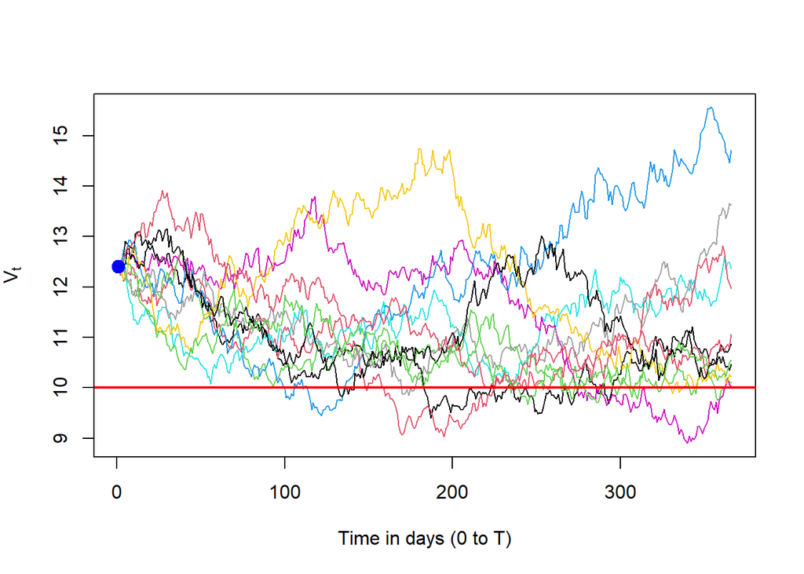

All these paths went lower than 10 at some point, but at the end the value of the assets are higher than 10. These are paralell universes in which the firm finally survived after some drama.

```r
# V_t < 10
almost_default <- which(colSums(paths < 10) > 0)
# V_T < 10
default <- which((paths[366,] < 10))
# There should be an easier way to do this:
matplot(paths[,almost_default[which(almost_default %in% default == FALSE)]],
        type = "l", col = c(1:11), lwd = 1, lty = 1,
        ylab = expression(paste(V[t])), xlab = "Time in days (0 to T)")
abline(h = D, col = "red", lwd = 2)
points(1, V0, pch = 19, cex = 1.5, col = "blue")
```

What if the asset value is decreasing over time $V_t \leq V_0$? Just as in the case of a physical assets that depreciates over time. What if we are interested in evaluating $V_t<D$ at any time, not only at maturity? Ideally, we should consider an alternative to the geometric brownian motion stochastic process in order to conduct our simulation analysis. However, we could consider a shortcut. This is, take the same GBM stochastic process and filter those paths which are $V_t \leq V_0$. There are some minor pitfalls here. For example, we still have some paths which show a decrease and then an increase. Those cases can be interpreted as if the depreciation is lower than an asset value increase. In any case, our approach delivers paths which never lead to an asset value higher than $V_0$.

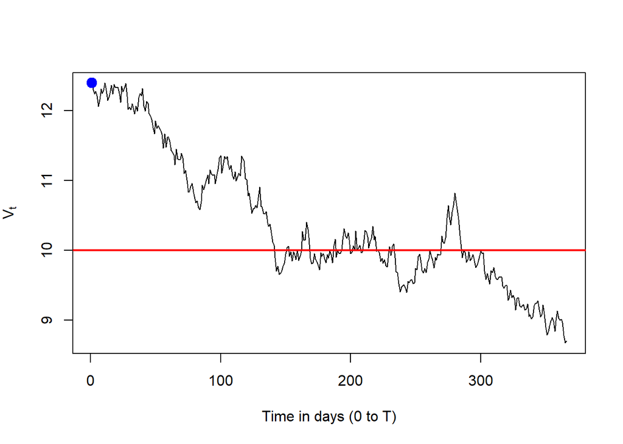

```r
set.seed(3) # Reproducibility
paths <- sapply(1:100, V0.sim) # Create 100 paths.
# Select those paths with all 366 values lower or equal than V0.
select.paths <- which(colSums(paths <= V0) == 366)
new.paths <- paths[,select.paths]
# Plot.
matplot(new.paths,
        type = "l", col = c(1:100), lwd = 1, lty = 1,
        ylab = expression(paste(V[t])),
        xlab = "Time in days (0 to T)")
abline(h = D, col = "red", lwd = 2)
points(1, V0, pch = 19, cex = 1.5, col = "blue")
```

```r
# Probability
sum(new.paths < 10) / length(new.paths)
```

```
## [1] 0.4754098
```

Here, only path number 49 out of 100 meet our condition. This path meets $V_t<D$ in 47.54098% of the cases. Let’s increase the number of simulations because 100 was apparently rather small. With 1,000 simulations the probability is 43.23445%. Let’s see the case of 10,000 simulations.

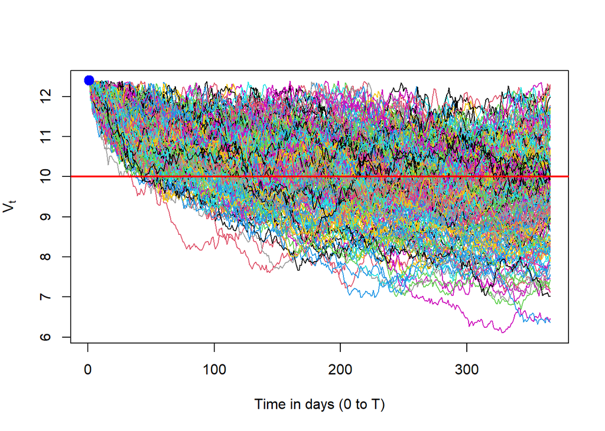

```r
set.seed(3) # Reproducibility
paths <- sapply(1:10000, V0.sim) # Create 10,000 paths.
# Select those paths with all 366 values lower or equal than V0.
select.paths <- which(colSums(paths <= V0) == 366)
new.paths <- paths[,select.paths]
# Plot.
matplot(new.paths,
        type = "l", col = c(1:10000), lwd = 1, lty = 1,
        ylab = expression(paste(V[t])),
        xlab = "Time in days (0 to T)")
abline(h = D, col = "red", lwd = 2)
points(1, V0, pch = 19, cex = 1.5, col = "blue")
```

```r
# Probability
sum(new.paths < 10) / length(new.paths)
```

```
## [1] 0.3596873
```

Now the probability is 35.96873%. We can consider this one as the final result for our purposes.

Here are 100,000 simulated $V_T$ showed in a histogram. The reference for this section is 15.1 (John C. Hull). Note that instead of drawing the complete paths, we can directly get the distribution of $V_T$. The resulting distribution is log-normal.

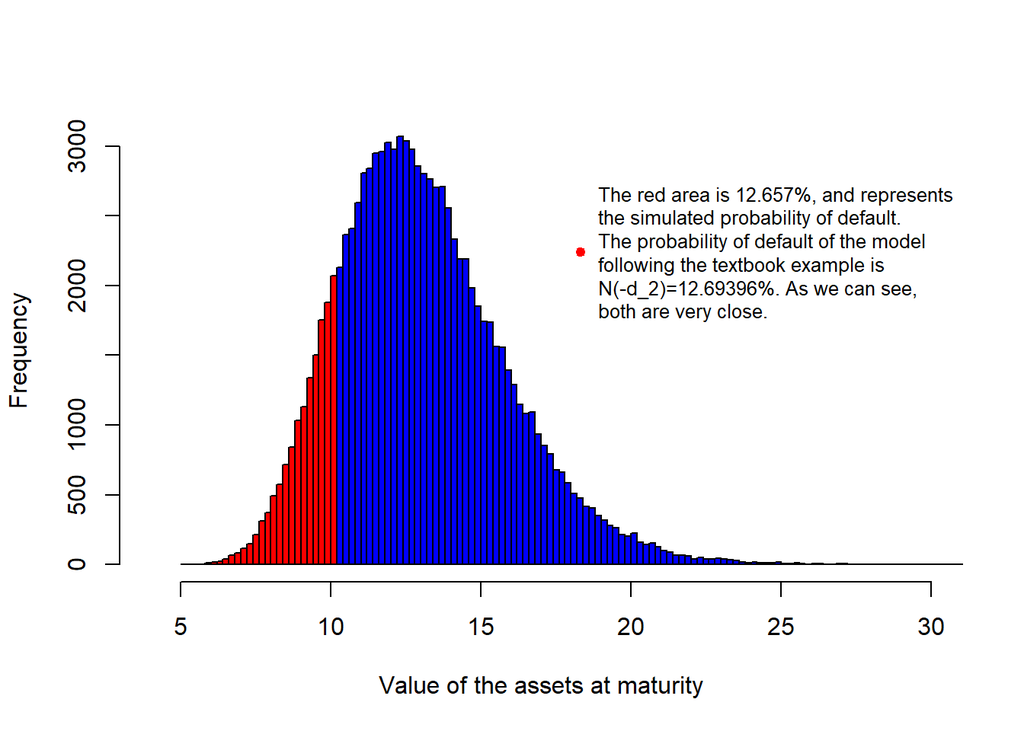

Histogram of 100,000 values of the assets at maturity.

```r
set.seed(13)
# 100,000 values of VT at once.
# Here, I added a TT value twice. This was not a mistake, because in the tutorial this value was equal to one. However, my students are trying with different maturities. For a formal reference please see equation 15.3 in Hull.
VT <- exp(rnorm(100000, log(V0) + (0.05 - (sv^2) / 2)*TT, sv*sqrt(TT)))
# Plot results.
# You may need to change the 100 if colors do not show properly. Sometimes this value is too high and bins are so many that it looks all black.
h <- hist(VT, 100, plot = FALSE)
ccat <- cut(h$breaks, c(-Inf, D, Inf))
# You may also need to change the xlim if a big red square appears as changes in maturity may imply larger values of VT. I recommend trying without xlim and see.
plot(h, main = NULL, col = c("red", "blue")[ccat],
     xlab = "Value of the assets at maturity", xlim = c(4, 30))
legend("topright",
legend = c("The red area is 12.657%, and represents
the simulated probability of default.
The probability of default of the model
following the textbook example is
N(-d_2)=12.69396%. As we can see,
both are very close."),
col = c("red", "blue"), pch = c(19), bg = "white", bty = "n", cex = 0.8)
```

The probability of default can be calculated as:

```r
sum(VT < 10) / 100000
```

```
## [1] 0.12657
```

Note that 0.12657 is now much closer than 0.12693963. Convergence achieved.

This firm can be represented as an European call option payoff. The payoff of a typical stock option is $c=max(S_T-K, 0)$ or equivalently in terms of Merton’s model: $E_T=max(V_T-D, 0)$.

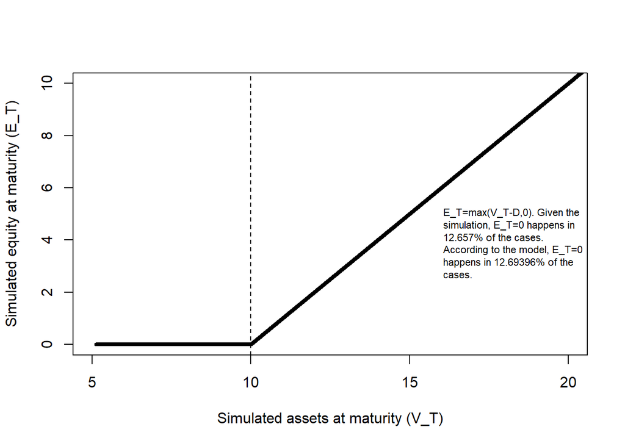

A view of the firm’s balance sheet in the future. Looks like a typical European call option payoff.

```r
ET <- pmax(VT - D, 0) # payoff function of a typical call option.
plot(sort(VT), sort(ET), type = "l", lwd = 4, xlim = c(5, 20),
     ylim = c(0, 10), xlab = "Simulated assets at maturity (V_T)",
     ylab ="Simulated equity at maturity (E_T)")
abline(v = 10, lty = 2)
legend("right", legend = c("E_T=max(V_T-D,0). Given the
simulation, E_T=0 happens in
12.657% of the cases.
According to the model, E_T=0
happens in 12.69396% of the
cases."),
bg = "white", bty = "n", cex = 0.7)
```

Then, we know that $E_T= max(V_T-D, 0)$. The Black???Scholes???Merton formula can also estimate the theoretical value of $E_0$. This is, if the observable market value given by the market capitalization available in any financial site is $E_0=3$, we can retrieve the theoretical value of $E_0$ so we can compare whether the firm observable market value is over or undervalued. In other words, the Black-Scholes-Merton model can give us an estimate of the firm value. In particular, the model gives the value of the equity today as:

$E_0=V_0N(d_1)-De^{-rT}N(d_2)$

This is equation 24.3 in Hull. To estimate $E_0$, we need $V_0$ and $\sigma_V$ and these two values were already estimated before with the implementation of the min.footnote10 function above. It is true that this minimization requires $E_0$, the point here is to use the observable market capitalization $E_0=3$ to find out the unobsevable $V_0$ and $\sigma_V$ and then estimate the theoretical value of $E_0$.

The code is:

```r
# Black-Scholes call.
E0.theo <- function(V0, D, rf, TT, sv) {
  d1 <- (log(V0 / D) + (rf + sv^2 / 2) * TT) / (sv * sqrt(TT))
  d2 <- d1 - sv * sqrt(TT)
  c <- V0 * pnorm(d1) - D * exp(-rf * TT) * pnorm(d2)
}
V0 <- 12.39578 # Assets.
D <- 10 # Debt.
rf <- 0.05 # Risk-free rate.
TT <- 1 # Maturity.
sv <- 0.2123041 # Volatility of assets.
(E0.theo(V0, D, rf, TT, sv))
```

```
## [1] 3.000357
```

Then, we can argue that the market value of the firm is slightly undervalued since the theoretical value of the firm is 3.000357 compared with 3. This approach opens the possibility to value firms. It also opens the possibility to compare the book value in the Balance sheet of the total assets versus the estimate $V_0$. This will allow us to understand the difference between book value and market value of the assets, not only of the equity. We can even implement a similar analysis about the market value of the debt just as we did before.

## The probability of default as a function of some parameters.

We can expand our analysis by evaluating how changes in parameters change the probability of default in the context of the Merton model. This is interesting because we can move from estimating a probability of default to propose changes in the firm’s parameters like the capital structure to reduce a firm’s probability of default. First, we need the probability of default as a function.

```r
pd <- function(E0, se, rf, TT, D) {
  eq24.3 <- function(V0, sv) {
  ((V0 * pnorm((log(V0 / D) + (rf + sv^2 / 2) * TT) / (sv * sqrt(TT))) -
  D * exp(-rf * TT) * pnorm(((log(V0 / D) +
  (rf + sv^2 / 2) * TT) / (sv * sqrt(TT))) - sv * sqrt(TT)) - E0)) }
eq24.4 <- function(V0, sv) {
  ((pnorm((log(V0 / D) + (rf + sv^2 / 2) * TT) / (sv * sqrt(TT))) *
      sv * V0 - se * E0)) }
  min.footnote10 <- function(x)
  (eq24.3(x[1], x[2]))^2 + (eq24.4(x[1], x[2]))^2
V0_sv <- optim(c(1, 1), min.footnote10)
V0 <- V0_sv$par[1]
sv <- V0_sv$par[2]
pd <- pnorm(-(((log(V0 / D) + (rf + sv^2 / 2) * TT) /
          (sv * sqrt(TT))) - sv * sqrt(TT)))
pd }
```

Now we have a convenient function: $pd = f(E_0, \sigma_E, rf, T, D)$. Remember these five parameters are required to estimate $V_0$ and $\sigma_V$ before calculating $pd$.

```r
# Evaluate the case of the textbook example.
pd1 <- pd(3, 0.8, 0.05, 1, 10)
pd1
```

```
## [1] 0.1269396
```

Now, we create vectors of parameters and evaluate the function.

```r
l = 50 # Vectors of length 50.
# Create vectors of the parameters.
x.E <- seq(from = 1, to = 20, length.out = l)
x.rf <- seq(0, 4, length.out = l)
x.D <- seq(1, 20, length.out = l)
x.T <- seq(0.5, 20, length.out = l)
x.se <- seq(0, 3, length.out = l)
# Evaluate the pd at different values.
pd.E <- mapply(pd, x.E, se, rf, TT, D)
pd.rf <- mapply(pd, E0, se, x.rf, TT, D)
pd.D <- mapply(pd, E0, se, rf, TT, x.D)
pd.T <- mapply(pd, E0, se, rf, x.T, D)
pd.se <- mapply(pd, E0, x.se, rf, TT, D)
```

```r
pd.E # vemos que hay en pd.E
```

```
##  [1] 0.15540348 0.14901392 0.14320202 0.13768571 0.13261199 0.12764964
##  [7] 0.12308008 0.11884785 0.11459711 0.11076647 0.10703359 0.10358685
## [13] 0.10027904 0.09705949 0.09400846 0.09099382 0.08829345 0.08564796
## [19] 0.08301610 0.08064451 0.07827914 0.07603520 0.07387230 0.07173820
## [25] 0.06986438 0.06783357 0.06602684 0.06416119 0.06256656 0.06089248
## [31] 0.05923871 0.05772111 0.05624785 0.05480055 0.05342181 0.05206815
## [37] 0.05076260 0.04952178 0.04825154 0.04709231 0.04595749 0.04482100
## [43] 0.04375887 0.04272127 0.04173439 0.04072829 0.03984186 0.03887309
## [49] 0.03795462 0.03714601
```

```r
# Busco el valor de pd mas parecido a 0.05
index <- which(almost.equal(pd.E, 0.05, tolerance = 0.01))
# ??Que numero de observacion es? (da 38 con los datos del tutorial)
index
```

```
## [1] 38
```

```r
# ??Que valor de equity me da una pd de 0.05?
x.E[index] # da 15.34694 con los datos del tutorial.
```

```
## [1] 15.34694
```

```r
pd.E[index] # da 0.04952178 con los datos del tutorial.
```

```
## [1] 0.04952178
```

Let’s plot the probability of default as a function of equity. What we are doing here is to evaluate the probability of default function 50 times, as the $E_0$ has 50 values from 1 to 20. By doing this, we end up with 50 values of the probability of default.

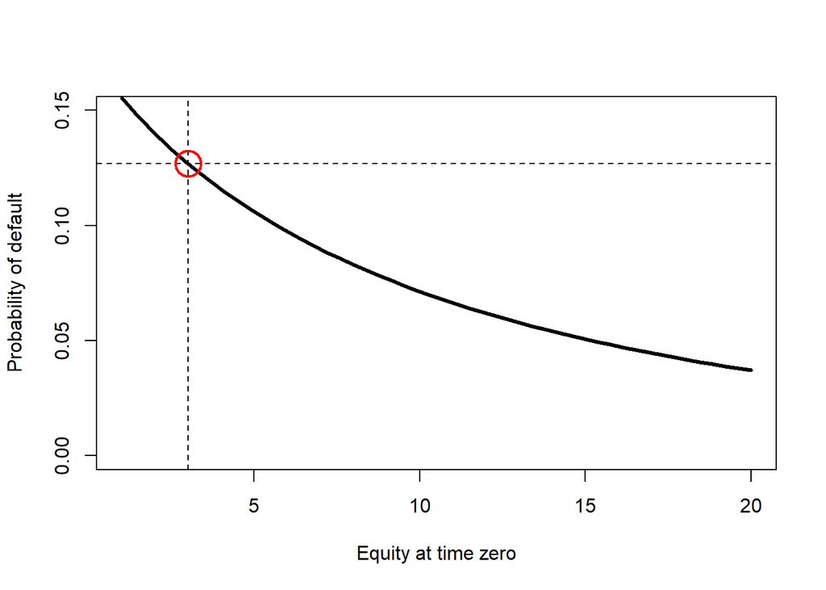

The probability of default as a function of the equity at time zero.

```r
plot(x.E, pd.E, type = "l", ylab = "Probability of default",
     xlab = "Equity at time zero", lwd = 3, ylim = c(0, 0.15))
lines(x.E, pd.E)
abline(v = E0, lty = 2)
abline(h = pd1, lty = 2)
points(E0, pd1, pch = 1, cex = 3, col = "red", lwd = 2)
```

These relationships between the parameters and the probability of default are all non-linear. This is interesting because according to the model, the current levels of the parameters are important when deciding which parameter might lead to a high or low impact over the probability of default.

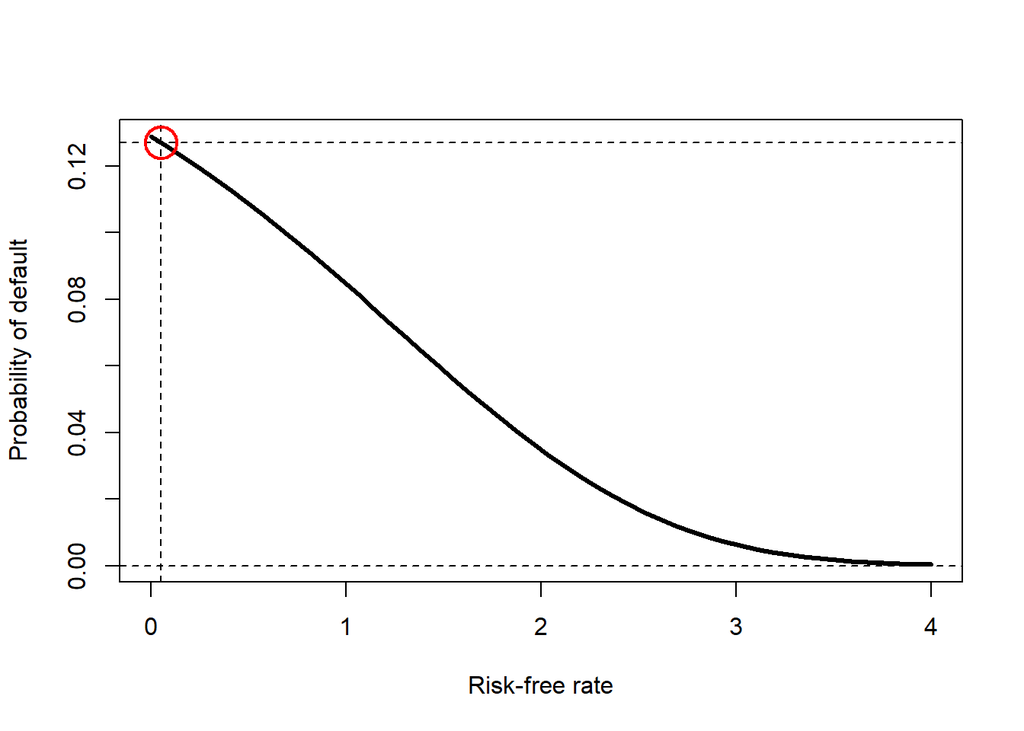

The probability of default as a function of the risk-free rate.

```r
plot(x.rf, pd.rf, type = "l", ylab = "Probability of default",
     xlab = "Risk-free rate", lwd = 3)
abline(h = 0, lty = 2)
abline(v = rf, lty = 2)
abline(h = pd1, lty = 2)
points(rf, pd1, pch = 1, cex = 3, col = "red", lwd = 2)
```